# Posit 入門繁中教材（Quarto＋Positron）

把買了看不完的線上課程，一鍵變成能讀完的筆記。

字級

Quarto 是什麼？（What Is Quarto?）Quarto 文件的構造（Anatomy of a Quarto Document）用 Markdown 寫作（Writing with Markdown）用 YAML 控制文件（Controlling Your Document with YAML）加入程式碼格（Adding Code Cells）Callout、交叉參照與更多功能（Callouts, Cross-References, and More）在自己的電腦上使用 Quarto（Using Quarto on Your Own Computer）課程總複習（Course Wrap-Up）

Positron 是什麼？（What is Positron?）Positron 的介面配置（The Positron Layout）核心面板與區域（Core Panes & Areas）Extensions、主題與快捷鍵（Extensions, Themes & Shortcuts）Interpreter 選擇與 Sessions（Interpreter Selection & Sessions）課程總複習（Course Recap）

用 Data Explorer 檢視資料檔（Viewing Data Files with the Data Explorer）把資料載入 Python 與 R（Loading Data into Python and R）用 Data Connections 連接資料庫（Connecting to Databases with Data Connections）分析資料：圖表、表格與 Viewer（Analyzing Data: Plots, Tables, and the Viewer）課程總複習（Course Recap）

執行腳本（Running Scripts）使用 Positron Notebook（Working with Positron Notebooks）建立專案與管理環境（Creating Projects and Managing Environments）用 Git 做版本控制（Version Control with Git）課程總複習（Course Recap）

# Posit 入門繁中教材（Quarto＋Positron）

把買了看不完的線上課程，一鍵變成能讀完的筆記。

**4**門課程**24**篇筆記**一鍵**自動整理

📘

## Quarto 入門（30 分）

· 8 篇

**🗺️ 本課地圖（點單元標題可跳到那一篇）**

[output not shown]

### Quarto 是什麼？（What Is Quarto?）

Quarto 入門 · 第 1 單元 · 約 8 分

一句話總結

**Quarto** 把文字、程式碼與結果放在同一個純文字 `.qmd` 檔裡，「渲染（render）」時重新執行程式碼並產出網頁、PDF、Word、簡報等成品，是 R Markdown 的多語言接班者。

你會學到

- Quarto 是什麼、解決什麼問題
- 渲染如何把 `.qmd` 原始檔變成成品
- 一份 Quarto 文件可以產出哪些種類的輸出
- Quarto 與 R Markdown 的關係、以及為何要做它

### 內容筆記

#### 文字、程式碼、結果放在同一處

多數資料工作的結尾，是把數字和圖從一個工具複製貼到另一個工具：跑完分析、把圖截圖貼進投影片或 Word、再手打一段解讀。資料一更新，一切重來，還得祈禱沒漏掉任何一個數字。Quarto 的解法是把**寫作、程式碼、結果**放進同一個檔案。

**Quarto** 是開源的出版系統，用「文字與程式碼混合的純文字檔」製作文件、簡報、網站等。每次建置（build）文件時程式碼都會重新執行，因此結果永遠與資料同步。

這種把「說明」與「程式碼」編織在一起的做法叫 **literate programming（文學式編程）**：不是「程式碼加幾行註解」，而是寫成一份人可以由上讀到下的文件，程式碼與其輸出就放在該出現的位置。

它帶來三個好處（原文為三張翻卡，內容如下）：

| 好處 | 說明 |
| --- | --- |
| **Reproducible（可重現）** | 結果來自執行程式碼，任何人重新建置文件都會得到相同數字 |
| **Always up to date（永遠最新）** | 有新資料？重新建置，所有表格、圖、數字自動更新 |
| **Plain text（純文字）** | Quarto 檔是純文字，可搭配版本控制（如 git）與任何編輯器 |

#### 從原始檔到成品

Quarto 文件寫在副檔名為 `.qmd` 的檔案中。`.qmd` 是**原始檔（source）**：純文字，含 markdown 格式，通常還有一些程式碼。它本身不適合直接拿來分享，要把它**渲染（render）**成成品。

下面把同一份文件的「原始檔」和「渲染結果」並排給你看。原始檔 `hello.qmd` 共 17 行：

````
---
title: "Weekly Temperatures"
author: "Ana Lopez"
format: html
---

## Summary

This week was **warmer** than last week,
peaking on *Saturday*.

```{r}
#| echo: false
temps <- c(18, 21, 24, 19, 23, 26, 25)
plot(temps, type = "b", pch = 19,
     xlab = "Day", ylab = "Temperature (°C)")
```
````

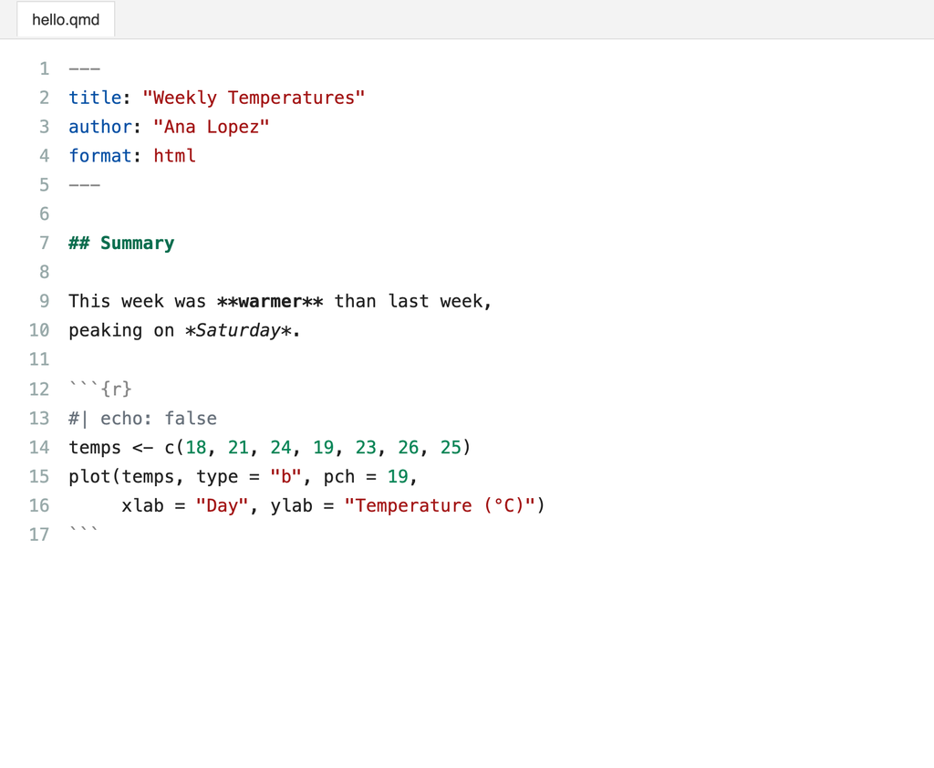

hello.qmd 原始檔截圖：最上方是含 title、author、format: html 的 YAML 標頭，接著是 ## Summary 標題、含 **warmer** 與 *Saturday* 標記的句子，最後是一段 R 程式碼區塊（#| echo: false 並畫出一週氣溫折線圖）

渲染成 HTML 後：最上方是大標題「Weekly Temperatures」，其下是作者名，然後是「Summary」標題、套好粗體（warmer）與斜體（Saturday）的句子，最後是一張一週氣溫（18、21、24、19、23、26、25 °C）的折線圖，**程式碼被隱藏**（因為 `echo: false`）。

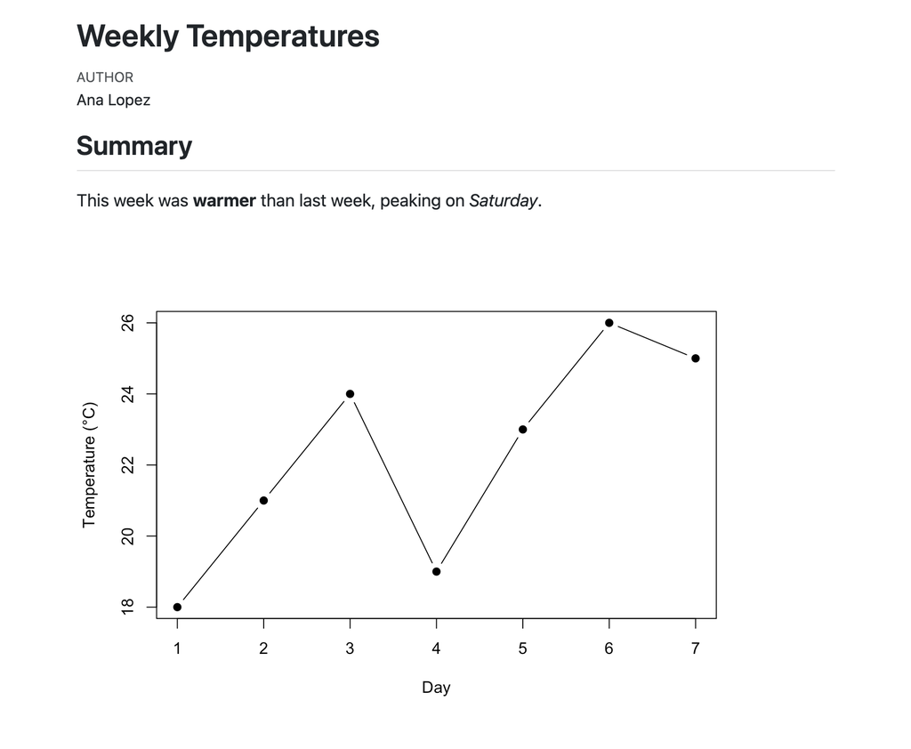

渲染後的網頁：大標題 Weekly Temperatures、作者 Ana Lopez、Summary 標題、套用粗體斜體的句子，以及第 1 到 7 天氣溫折線圖，程式碼未顯示

#### 渲染時發生什麼事

渲染分幾個步驟，Quarto 全部代勞：

[figure not shown]

渲染流程圖：hello.qmd（文字加程式碼）→ 執行程式碼（R、Python 等）→ Markdown（文字加結果）→ 輸出（HTML、PDF、Word 等）

1. Quarto 執行文件中每一個程式碼格（code cell），語言可以是 R、Python 或其他。
2. 把結果（數字、表格、圖）放回程式碼原本所在位置的文字中。
3. 把合併後的文字轉成你指定的格式：網頁、PDF、Word 等。

原始檔不會被改動

渲染會在原始檔旁邊產生一個**新檔案**，例如 `hello.html`，**絕不會修改你的 `.qmd`**。工作流程就是：編輯原始檔 → 渲染 → 看輸出 → 重複。

#### 一份原始檔，多種格式

Quarto 最厲害之處：同一份 `.qmd` 可以變成截然不同的東西，只要改檔案最上方的一行就能切換。原文列出的輸出類型：

| 類型 | 說明 |
| --- | --- |
| HTML documents | 可在任何瀏覽器開啟的網頁，有分頁籤、可折疊程式碼、提示框等互動功能 |
| PDF | 精緻、可列印的報告或論文，用 LaTeX 或 Typst 排版 |
| Word | Microsoft Word 文件，適合同事要編輯、加註解時 |
| Presentations | 簡報：reveal.js（HTML）、PowerPoint 或 Beamer，皆由同一份 markdown 產生 |
| Websites and blogs | 把多份文件組成有導覽與搜尋的完整網站 |
| Books | 多章節書籍，有交互參照，可發佈成 HTML、PDF 或 ePub |
| Dashboards | 把圖、表、數值排成一目了然的儀表板 |

支援多種語言

Quarto 可寫 R、Python、Julia 或 Observable JavaScript 的程式碼；若文件以文字為主，你甚至不需要會其中任何一種。

想看大家做了什麼，可瀏覽 [Quarto Gallery](https://quarto.org/docs/gallery/)。

#### 從 R Markdown 轉過來？

若你用過 R，可能聽過 **R Markdown**：`.Rmd` 檔混合文字與 R 程式碼，可渲染成 HTML、PDF 或 Word。它已存在十年以上、仍被廣泛使用。本課不需要會它，但知道來龍去脈有幫助。

Quarto 是 R Markdown 的**下一代**，由同一個團隊 Posit 打造，把 R Markdown 累積的經驗重建成一個「不綁定 R」的系統。

| 面向 | R Markdown | Quarto |
| --- | --- | --- |
| 本質 | 一個 R 套件，必須安裝 R | 獨立工具，不需要 R |
| 語言 | 主要是 R | R、Python、Julia、Observable JavaScript |
| 進階功能 | 靠額外套件：bookdown 做書、blogdown 做網站、xaringan 做簡報 | 書、網站、簡報、交互參照等都內建，語法一致 |

你的 R Markdown 成果不會浪費

Quarto 可以不修改直接渲染大多數 `.Rmd` 檔，而且很多語法相同。R Markdown 也不會消失，仍有維護，現有專案不必急著換。只是新功能都會出現在 Quarto。

### 關鍵詞

- **Quarto**：開源出版系統，用混合文字與程式碼的純文字檔產出文件、簡報、網站等。
- **literate programming（文學式編程）**：把說明與程式碼編織成一份可由上讀到下的文件。
- **`.qmd`**：Quarto 原始檔，純文字，含 markdown 與（常見的）程式碼。
- **render（渲染）**：執行程式碼並把 `.qmd` 轉成成品；產生新檔、不改原始檔。
- **R Markdown（`.Rmd`）**：Quarto 的前身，綁定 R 的套件。

### 可執行要點

- 記住流程：`.qmd`（原始檔）→ 執行程式碼 → markdown → 輸出成品
- 把「複製貼上圖表到 Word／投影片」的習慣，改想成「改資料、重新渲染」
- 若手上有舊的 `.Rmd`，之後可直接試著用 Quarto 渲染看看
- 逛一下 Quarto Gallery 找靈感

📝 隨堂測驗（點選項作答）

你把 report.qmd 渲染成 HTML 之後，report.qmd 會怎樣？

渲染會在原始檔旁產生新檔案，絕不改動 .qmd 本身。

下列哪些是 Quarto 被做成 R Markdown 接班者的理由？（單選：最正確者）

Quarto 內建多種功能、不綁 R；它仍使用 markdown，且 R Markdown 仍在維護、多數 .Rmd 可直接渲染。

想把同一份報告改成可讓同事用 Word 編輯並加註解，最直接的做法是？

同一份 .qmd 只需改最上方的格式設定（format）就能切換輸出類型。

### Quarto 文件的構造（Anatomy of a Quarto Document）

Quarto 入門 · 第 2 單元 · 約 6 分

一句話總結

每份 `.qmd` 都由三部分組成：**YAML 標頭**（整份文件的設定）、**markdown 文字**（變成排版後的內文）、**程式碼格**（渲染時執行、結果出現在輸出中）。

你會學到

- 每份 Quarto 文件都有的三個部分
- 每個部分在渲染後會變成什麼
- 如何在本課使用的瀏覽器版 Quarto 模擬器中編輯並渲染（本筆記改寫成在你自己的 `.qmd` 動手試）

### 內容筆記

#### 三個組成部分

每個 `.qmd` 檔都由同樣三種材料構成。下面是一份小而完整的 Quarto 文件，回報一週氣溫的平均：

````
---
title: "Weekly Temperatures"
format: html
---

## Summary

This week was **warmer** than last week.

```{python}
temps = [18, 21, 24, 19, 23]
sum(temps) / len(temps)
```
````

一開始符號看起來很多，但拆開來就是三塊，各有職責：

| 部分 | 長相 | 作用 |
| --- | --- | --- |
| **YAML header（YAML 標頭）** | 檔案最上方兩條 `---` 線之間的區塊 | 設定整份文件的選項，如標題與輸出格式 |
| **Markdown text（markdown 文字）** | 一般文字加上 `##`、`**` 等符號 | 變成排版後的文字：標題、粗體、清單、連結 |
| **Code cells（程式碼格）** | 以 `` ```{r} `` 或 `` ```{python} `` 開頭的區塊 | 渲染時執行，結果顯示在輸出中 |

Code cells 與 code chunks

用過 R Markdown 的人熟悉的「code chunk（程式碼區塊）」，在 Quarto 叫 **code cell**，是同一個概念、新名稱。

#### 動手試：第一次渲染

原課程提供瀏覽器內的 **Quarto 模擬器**（左側編輯器、右側預覽，不用安裝任何東西）。它使用 Quarto 自己的格式化引擎，所以預覽結果與真正的 Quarto 一致；但**只能預覽 HTML**、也讀不到你電腦裡的檔案。本筆記改成請你在自己的環境操作（第 7 單元會教如何在自己電腦上用 Quarto）。本例用 Python，但這一課不需要你寫任何程式。

**動手試：** 在你自己的 `.qmd` 輸入上面那份完整文件（模擬器載入的就是它，程式碼格內是 `temps = [18, 21, 24, 19, 23]` 與 `sum(temps) / len(temps)`），渲染後依序做三個修改，每改一次就重新渲染一次：

1. 把 YAML 標頭的 `title` 改成別的，例如 `"My First Quarto Document"`。
2. 把文字中的 `warmer` 改成 `cooler`。
3. 改 `temps` 其中一個數字，例如把 `24` 改成 `30`。

**預期結果：** 標題改了、文字改了、而且改數字後平均值會自動更新。你會看到：YAML 的 title 變成頂端的大標題、markdown 變成排版文字、程式碼格同時顯示程式碼與其結果。這就是 Quarto 的核心觀念：**結果永遠來自執行程式碼**。

改亂了？

模擬器把你的編輯存在瀏覽器裡，按編輯器上方的 **Reset** 可還原成原本的文件。（在自己電腦上則可用版本控制或重新貼上原文。）

#### 分辨哪個片段屬於哪一部分

接下來三個單元會逐一深入這三部分。先確認你分得清楚，下面是原課程的分類練習（原為拖曳，這裡直接給答案）：

| 片段 | 屬於 |
| --- | --- |
| `title: "Sales Report"` | YAML 標頭 |
| `format: html` | YAML 標頭 |
| `## Results` | markdown 文字 |
| `This week was warmer.` | markdown 文字 |
| `max(temps)` | 程式碼格 |
| `sum(temps) / len(temps)` | 程式碼格 |

判準：**整份文件的選項放 YAML 標頭；你寫的文字是 markdown；需要執行的東西放程式碼格。**

### 關鍵詞

- **YAML header**：檔案最上方被兩條 `---` 包住的設定區。
- **Markdown text**：用簡單符號標記格式的內文。
- **Code cell**：會在渲染時執行並顯示結果的程式碼區塊（R Markdown 稱 code chunk）。
- **Quarto simulator**：原課程內建的瀏覽器版編輯與預覽環境，只預覽 HTML。

### 可執行要點

- 在自己的 `.qmd` 貼上範例文件並渲染一次
- 依序改標題、改文字、改數字，各渲染一次，確認每一處變動對應到輸出
- 看到任一片段時，先判斷它是 YAML、markdown 還是 code cell

📝 隨堂測驗（點選項作答）

`format: html` 這一行應該放在哪一部分？

影響整份文件的選項（如標題、輸出格式）放在 YAML 標頭。

你把程式碼格中的 temps 某個數字改掉並重新渲染，輸出中的平均值會怎樣？

渲染時會重新執行程式碼，所以結果永遠與程式碼／資料同步。

### 用 Markdown 寫作（Writing with Markdown）

Quarto 入門 · 第 3 單元 · 約 10 分

你會學到

- 什麼是 markdown、Quarto 為何使用它
- 如何寫標題、粗體、斜體與行內程式碼
- 如何做項目清單、編號清單、連結與圖片
- 如何替圖片加上給螢幕閱讀器用的替代文字（`fig-alt`）

### 內容筆記

#### Markdown 速覽

最常用語法一覽：

[output not shown]

#### 標題

一行以 `#` 開頭就是標題，`#` 的數量決定層級：`##` 是章節、`###` 是其下的小節，依此類推。

```
## Results

### By region
```

為什麼不用單一個 `#`？

YAML 標頭裡的 `title` 本身就是最頂層標題，所以多數 Quarto 文件的章節從 `##` 開始。另外 `#` 後面**要留一個空格**：`## Results` 是標題，`##Results` 不是。

#### 粗體、斜體與行內程式碼

**動手試（markdown playground）：** 原課程的練習場會邊打邊即時更新預覽。請在你自己的 `.qmd` 輸入以下內容，改幾個字、加一個標題，看渲染結果：

```
---
title: "Markdown Playground"
---

## A heading

Some **bold** text, some *italic* text, and a file name like `report.qmd`.

### A smaller heading

Try making *this sentence* bold instead.
```

預期結果：`## A heading` 顯示為較大的章節標題、`### A smaller heading` 為較小的小節標題；「bold」粗體、「italic」斜體、`report.qmd` 以程式碼字型顯示。

#### 清單

每行以 `-` 開頭是項目清單；以「數字加句點」開頭是編號清單：

```
- Flour
- Milk
- Eggs
```

```
1. Mix the batter
2. Heat the pan
3. Cook both sides
```

清單前要空一行

清單與上方的段落之間必須有一個空行。沒有的話，markdown 會把清單項目當成段落的一部分，全部擠成同一行。這是最常見的 markdown 錯誤，清單長得不對時先檢查這個。

#### 連結與圖片

連結：中括號放要顯示的文字，後面緊接小括號放網址。圖片：同樣的寫法，**前面加一個 `!`**。當圖片單獨成一行時，中括號裡的文字會成為圖說（caption）。再用大括號加上 `fig-alt` 屬性，描述圖片給使用螢幕閱讀器的人：

```
Learn more on the [Quarto website](https://quarto.org).

![Daily highs for the week](temps.png){fig-alt="A line chart of daily high temperatures rising from 15 to 24 degrees over seven days."}
```

#### 練習：幫食譜加格式

下面這份食譜文字都對、卻完全沒有格式（原課程在模擬器中，按 Render 才更新）：

```
---
title: "Pancakes"
---

Ingredients

1 cup flour

1 cup milk

1 egg

Steps

Whisk everything together.

Cook on a hot pan for 2 minutes per side.

Serve warm.

Do not overmix the batter.
```

**動手試：** 把它貼進你自己的 `.qmd`，先渲染看看，再用 markdown 做四件事：

1. 把 `Ingredients` 與 `Steps` 改成二級標題（`##`）。
2. 三樣食材改成項目清單。
3. 三個步驟改成編號清單。
4. 把 `Do not overmix the batter.` 整句改成粗體。

提示：二級標題是兩個 `#` 加空格；每項食材以 `-` 開頭、步驟以 `1.`、`2.`、`3.` 開頭，且標題與清單之間要空一行；整句粗體是前後各包兩個星號。

**參考答案：**

```
---
title: "Pancakes"
---

## Ingredients

- 1 cup flour
- 1 cup milk
- 1 egg

## Steps

1. Whisk everything together.
2. Cook on a hot pan for 2 minutes per side.
3. Serve warm.

**Do not overmix the batter.**
```

### 關鍵詞

- **Markdown**：用簡單符號為純文字加格式的語法。
- **`fig-alt`**：圖片的替代文字屬性，給螢幕閱讀器使用者描述圖片。
- **行內程式碼（inline code）**：用單一反引號包住、以程式碼字型顯示的文字。
- **caption（圖說）**：獨立成行的圖片，中括號中的文字會成為它的說明。

### 可執行要點

- 在 `.qmd` 練習標題（`##`、`###`）、粗體、斜體、行內程式碼各一次
- 每次寫清單前，先確認上方有一個空行
- 加圖片時順手補上 `{fig-alt="..."}`
- 把「食譜」練習自己做一遍並對照參考答案

📝 隨堂測驗（點選項作答）

哪一行會把「the docs」這幾個字連到 https://quarto.org？

清單項目渲染後全擠成同一行，最可能的原因是？

清單與上方段落之間需要一個空行，否則會被當成段落的一部分。

為什麼多數 Quarto 文件的章節標題從 `##` 而不是 `#` 開始？

文件 title 本身就扮演最上層標題，章節因此從 ## 開始。

### 用 YAML 控制文件（Controlling Your Document with YAML）

Quarto 入門 · 第 4 單元 · 約 15 分

一句話總結

YAML 標頭是整份文件的控制面板：用 `key: value` 設定標題、作者、日期，用 **`format`** 選輸出格式（html、typst/pdf、docx、revealjs…），一份原始檔可同時產出多種格式；頂層選項套用到所有格式，縮排在某格式底下的選項只套用該格式。

你會學到

- YAML 選項如何運作，以及最容易出錯的語法規則
- 如何設定文件的 title、author、date
- 如何選擇輸出格式，以及一份文件如何同時產出多種格式
- 如何找出並修正 YAML 標頭的錯誤

### 內容筆記

#### YAML 怎麼運作

標頭位於 `.qmd` 檔最上方，夾在兩行三個破折號（`---`）之間。裡面用 **YAML** 撰寫，這是一種簡單的設定格式。每一行是一組 `key: value`：選項名稱、冒號、一個空格、你要的值。

```
---
title: "Quarterly Sales Report"
subtitle: "Third quarter"
author: "Ana Lopez"
date: today
---
```

| 選項 | 設定什麼 |
| --- | --- |
| `title` | 文件頂端的大標題 |
| `subtitle` | 標題下方較小的一行 |
| `author` | 作者 |
| `date` | 日期，或用 `today` 表示渲染當天 |

人人都會踩的三條 YAML 規則

1. **冒號後要留一個空格。** `author: Ana` 可以；`author:Ana` 不行。
2. **含冒號的文字要加引號。** `title: "Sales: Q3"` 可以；少了引號，YAML 會以為第二個冒號開啟了新選項。
3. **縮排用空格，絕不用 Tab。** 縮排表示哪些選項屬於另一個選項之內，所以必須一致；通常一層兩個空格。

#### 選擇輸出格式

`format` 選項決定 Quarto 產出哪種檔案，文件其餘內容完全不變。下面是存成 `report.qmd` 的一份短報告（含標題、清單、表格與一段 Python 畫圖的程式碼格）：

````
---
title: "Quarterly Sales Report"
author: "Ana Lopez"
format: html
---

## Highlights

Sales grew **12%** this quarter, led by the *West* region.

- Two new regions opened
- Returns fell to a record low
- Online orders passed in-store orders

## Sales by Region

| Region | Sales | Change |
|--------|------:|--------|
| North  |   120 | Up     |
| South  |    95 | Down   |
| West   |   143 | Up     |

## Monthly Trend

```{python}
#| echo: false
import matplotlib.pyplot as plt

plt.figure(figsize=(6, 3))
plt.plot(["Jul", "Aug", "Sep"], [102, 115, 128], marker="o")
plt.ylabel("Sales (thousands)")
plt.show()
```
````

只改 `format` 這一行再渲染，結果如下（原文為四個分頁籤，這裡全部展開）：

| `format` 設定 | 產出檔 | 說明 |
| --- | --- | --- |
| `format: html` | `report.html` | 可在任何瀏覽器開啟的網頁；**未設定 format 時的預設值** |
| `format: typst` | `report.pdf` | 用 Typst 排版的 PDF，可列印或當附件寄出 |
| `format: docx` | `report.docx` | Microsoft Word 文件，同事可編輯與加註解 |
| `format: revealjs` | `report.html` | reveal.js 簡報，在瀏覽器中播放；標題與作者成為標題投影片，每個 `##` 標題開啟一張新投影片 |

**HTML 版**：大標題、作者、帶底線的章節標題、項目清單、有樣式的表格，以及七至九月（Jul、Aug、Sep；銷售 102、115、128 千）的折線圖。

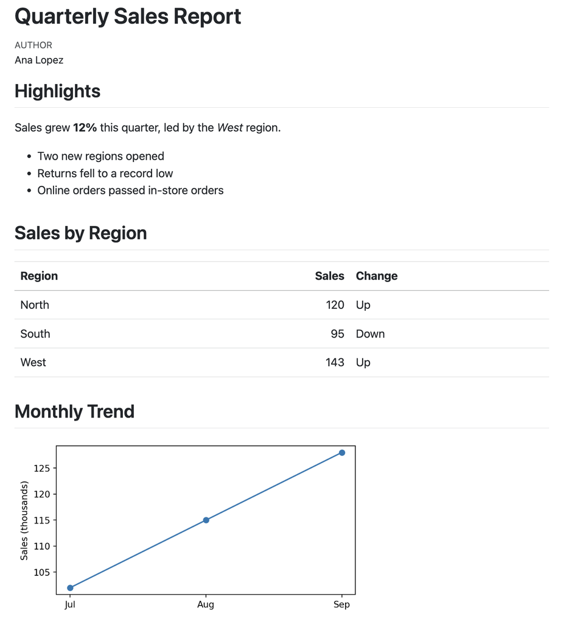

HTML 版報告：大標題 Quarterly Sales Report、作者 Ana Lopez、Highlights 條列、Sales by Region 表格（North 120 Up、South 95 Down、West 143 Up）與 Jul 到 Sep 銷售折線圖

**PDF（Typst）版**：標題與作者置中、襯線字體、較緊湊的表格。

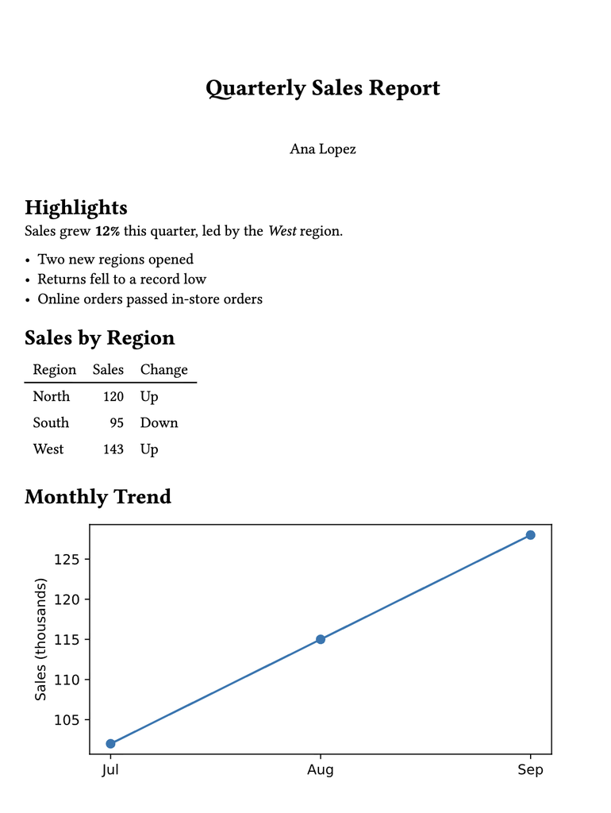

Typst 產出的 PDF 頁面：置中的襯線字體標題與作者、Highlights 條列、緊湊的 Sales by Region 表格與 Monthly Trend 折線圖

**Word 版**：標題與作者置中、藍色章節標題、簡單表格與折線圖。

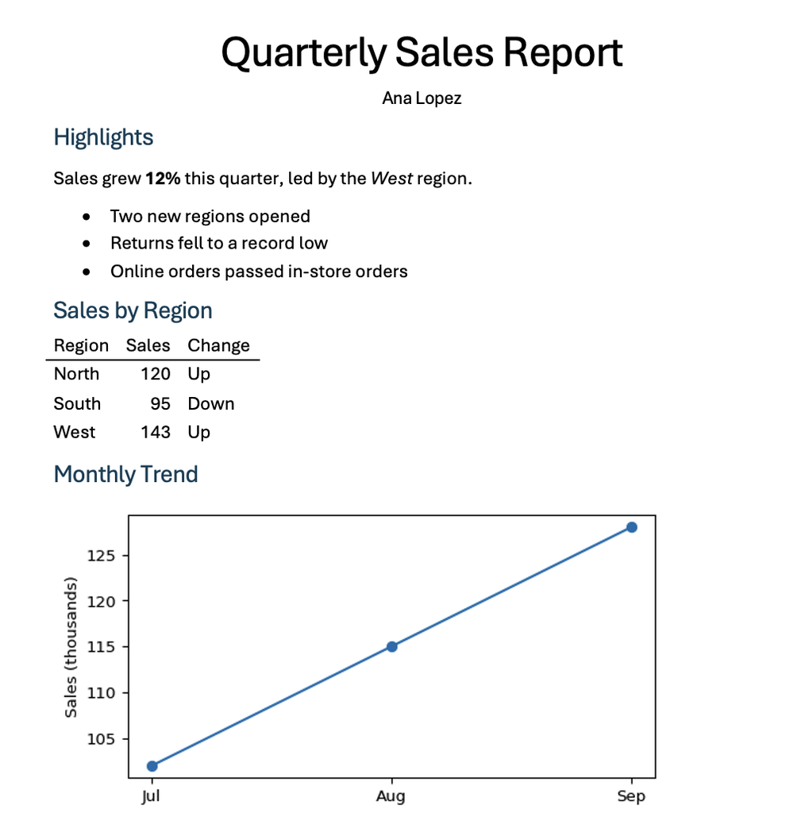

Word 文件版本：置中標題與作者、藍色章節標題、條列、簡單表格與折線圖

**Slides 版**：標題投影片只顯示大字的「Quarterly Sales Report」與下方的「Ana Lopez」。

做 PDF 有兩種方式

- **`format: typst`**：用 Typst（現代排版系統，隨 Quarto 附帶）。速度快、不用另外安裝任何東西，callout 等功能的外觀跟 HTML 很像。
- **`format: pdf`**：用 LaTeX（歷史悠久的排版系統，需另外安裝）。

除非你已經在用 LaTeX，否則從 `format: typst` 開始。

模擬器只預覽 HTML

原課程的 Quarto 模擬器只預覽 HTML；設成其他格式時，它會顯示提示並改預覽 HTML。在你自己的電腦上 Quarto 會產出真正的 PDF、Word 或簡報檔（第 7 單元會教）。

小測：同事想用 Word 編輯並加註解你的報告，要渲染成哪個格式？答案是 `format: docx`。

#### 格式選項：一份來源，多種格式

把多個格式列在 `format` 底下，各佔一行。`default` 代表「這個格式，不做任何更改」：

```
---
title: "Quarterly Sales Report"
format:
  html: default
  docx: default
---
```

渲染後，同一個檔案產出網頁**和** Word 文件。選項可以在兩個層級設定。

**所有格式共用的選項**放在標頭最上層，與 `title` 並排。下例 `number-sections: true` 讓網頁與 Word 文件的標題都自動編號：

```
---
title: "Quarterly Sales Report"
number-sections: true
format:
  html: default
  docx: default
---
```

**只給單一格式的選項**，縮排放在該格式名稱底下。下例兩份檔案仍都有章節編號，但只有網頁會把程式碼折疊在一個 **Code** 按鈕後面；Word 文件無法折疊程式碼，因此 `code-fold` 是 HTML 專屬選項：

```
---
title: "Quarterly Sales Report"
number-sections: true
format:
  html:
    code-fold: true
  docx: default
---
```

注意縮排：`code-fold` 縮在 `html:` 之下，`html:` 又縮在 `format:` 之下，YAML 才知道它是 HTML 的選項。**若同一個選項在兩個層級都設定，格式內層的那個優先**（只對該格式生效）。

**動手試：** 在你自己的 `.qmd` 貼上下面這份使用簡寫 `format: html` 的文件：

````
---
title: "Quarterly Sales Report"
format: html
---

## Revenue

Revenue grew in every region.

```{python}
regions = {"North": 120, "South": 95, "West": 143}
sum(regions.values())
```

## Costs

Costs stayed flat.
````

把 `format: html` 改成帶選項的長寫法，並開啟 `number-sections` 與 `code-fold`：

```
format:
  html:
    number-sections: true
    code-fold: true
```

**預期結果：** 每個標題前出現編號，程式碼格被折疊在一個 **Code** 按鈕後面。

去哪裡找所有選項？

每個格式在 Quarto 官方參考文件都有完整選項列表：[HTML](https://quarto.org/docs/reference/formats/html.html)、[Typst](https://quarto.org/docs/reference/formats/typst.html)、[PDF（LaTeX）](https://quarto.org/docs/reference/formats/pdf.html)、[Word](https://quarto.org/docs/reference/formats/docx.html)。不需要全部學會，想改什麼再去查。

#### 練習：修好壞掉的標頭

下面這個標頭有三個錯誤。原課程要你先渲染、讀錯誤訊息（模擬器會指出出問題的那一行），逐一修好直到文件能渲染且章節有編號：

```
---
title: Sales Report: Q3
author:Ana Lopez
format:
  html:
  number-sections: true
---
```

（原課程文件在標頭後有兩節：`## Revenue`「Revenue grew in every region.」與 `## Costs`「Costs stayed flat.」。）

提示對應三條規則：

1. `title` 含冒號 → 需要加引號包住。
2. `author:Ana Lopez` → 冒號後要有空格。
3. `number-sections: true` 的縮排要比 `html:` 更深，才算是 HTML 的選項。

**參考答案：**

```
---
title: "Sales Report: Q3"
author: Ana Lopez
format:
  html:
    number-sections: true
---
```

### 關鍵詞

- **YAML**：簡單的設定語法，每行 `key: value`。
- **`format`**：決定輸出格式的選項：`html`、`typst`、`pdf`、`docx`、`revealjs` 等。
- **`default`**：`html: default` 表示該格式、不改任何設定。
- **Typst / LaTeX**：兩種排版 PDF 的系統；Typst 隨 Quarto 附帶，LaTeX 需另裝。
- **reveal.js**：在瀏覽器播放的簡報格式，`##` 標題開啟新投影片。
- **`number-sections`**：自動幫標題編號。
- **`code-fold`**：HTML 專屬選項，把程式碼折疊在 Code 按鈕後。

### 可執行要點

- 寫 YAML 時自我檢查三條規則：冒號後空格、含冒號要引號、縮排用空格
- 把同一份報告分別試 `html`、`typst`、`docx`、`revealjs`
- 需要 PDF 時先用 `format: typst`
- 想同時輸出多格式時，在 `format:` 下各列一行並用 `default`
- 共用選項放頂層；只給單一格式的選項縮排放在格式名稱下

📝 隨堂測驗（點選項作答）

同事要在 Microsoft Word 編輯並加註解你的報告，應渲染哪個格式？

docx 產出 Word 文件；typst 產 PDF、revealjs 產簡報、html 產網頁。

下列哪個 title 寫法是正確的 YAML？

含冒號的文字要加引號，且冒號後要留空格。

`code-fold: true` 只縮排在 `html:` 底下，同時輸出 docx，結果是？

縮排在某格式下的選項只套用該格式；code-fold 本來也是 HTML 專屬選項。

想產生 PDF 且不想另外安裝任何東西，該用？

typst 隨 Quarto 附帶；format: pdf 用 LaTeX，需另外安裝。

### 加入程式碼格（Adding Code Cells）

Quarto 入門 · 第 5 單元 · 約 10 分

一句話總結

**程式碼格**以 `` ```{r} `` 或 `` ```{python} `` 開頭、渲染時執行並把結果放在下方；用以 `#|` 開頭的**格選項**（`echo`、`eval`、`include`、`label`、`fig-cap`）逐格控制輸出內容。

你會學到

- 如何寫 R 或 Python 程式碼格
- 文件渲染時程式碼格會發生什麼事
- 如何用 `echo`、`eval`、`label`、`fig-cap` 等格選項控制輸出

### 內容筆記

#### 程式碼格是什麼

程式碼格讓 Quarto 文件不只是排版文字。它以三個反引號加大括號內的語言名稱開頭，以三個反引號結尾。渲染時 Quarto 執行程式碼，把結果放在它的正下方。

R 版：

````
```{r}
temps <- c(18, 21, 24, 19, 23)
mean(temps)
```
````

輸出：

```
[1] 21
```

Python 版：

````
```{python}
temps = [18, 21, 24, 19, 23]
sum(temps) / len(temps)
```
````

輸出：

```
21.0
```

其他語言與多格混用

Quarto 也支援 Julia 與 Observable JavaScript，寫法相同：`` ```{julia} ``、`` ```{ojs} ``。一份文件可以有多個程式碼格，夾雜大量文字。**格子由上到下依序執行**，所以後面的格子可以使用前面格子建立的東西。

從 R Markdown 轉來？

Quarto 用 **knitr**（R Markdown 背後同一個引擎）執行 R 格，所以你的 R 程式碼（幾乎）運作得一模一樣。主要差別是**格選項的位置**：R Markdown 寫在格子標頭，如 `` ```{r, echo=FALSE} ``；Quarto 寫在格子**裡面**以 `#|` 開頭的行。舊寫法仍可用，但 `#|` 寫法對 R 與 Python 都一樣。

#### 格選項（cell options）

預設輸出會同時顯示程式碼與結果。這對教學很好，但給主管的報告大概只需要圖表。**格選項**讓你逐格控制。

格選項放在格子的**最上方**，每行以 `#|`（井字號加直線）開頭，語法與 YAML 標頭相同，都是 `key: value`：

````
```{python}
#| echo: false
plt.plot(temps)
```
````

最常用的選項：

| 選項 | 作用 |
| --- | --- |
| `echo: false` | 隱藏程式碼，但仍顯示結果 |
| `eval: false` | 顯示程式碼，但不執行 |
| `include: false` | 執行程式碼，但程式碼與結果都不顯示 |
| `label: fig-temps` | 替格子取名，之後可在別處參照它的圖；圖的標籤以 `fig-` 開頭 |
| `fig-cap: "Daily temperatures"` | 在該格的圖下方加圖說 |

整份文件設定一次

想隱藏每個格子的程式碼，不用每格重複寫，可在 YAML 標頭的 `execute:` 底下設定 `echo: false`：

```
execute:
  echo: false
```

**動手試：** 在你自己的 `.qmd` 貼上下面的文件（需要 Python 與 matplotlib），先渲染看到圖；再在格子第一行加 `#| echo: false` 重新渲染；然後改試 `#| eval: false` 看有什麼不同。

````
---
title: "Weekly Temperatures"
---

```{python}
import matplotlib.pyplot as plt

temps = [18, 21, 24, 19, 23, 26, 25]
plt.plot(range(1, 8), temps, marker="o")
plt.xlabel("Day")
plt.ylabel("Temperature (°C)")
plt.show()
```
````

**預期結果：** 預設顯示程式碼與折線圖；加 `echo: false` 後只剩圖；改 `eval: false` 後只剩程式碼、沒有圖（因為沒有執行）。

小測：報告要顯示圖表、但不要顯示畫圖的程式碼，該加哪個選項？答案是 `#| echo: false`（`eval: false` 是不執行；`include: false` 連結果都藏起來）。

#### 練習：把報告修整到可分享

下面這份報告可以運作，但顯示了畫圖程式碼、圖也沒有圖說：

````
---
title: "Weekly Temperatures"
---

The average temperature this week was:

```{python}
temps = [18, 21, 24, 19, 23, 26, 25]
sum(temps) / len(temps)
```

```{python}
import matplotlib.pyplot as plt

plt.plot(range(1, 8), temps, marker="o")
plt.xlabel("Day")
plt.ylabel("Temperature (°C)")
plt.show()
```
````

**動手試：**

1. 隱藏畫圖的程式碼，但保留圖。
2. 把畫圖的格子標籤設為 `fig-temps`。
3. 圖說設為 `Daily temperatures`。

三項都是**第二個格子**的格選項，各佔一行、以 `#|` 開頭、放在格子最上方；你需要 `echo`、`label`、`fig-cap`，圖說文字要加引號。

**參考答案：**

````
---
title: "Weekly Temperatures"
---

The average temperature this week was:

```{python}
temps = [18, 21, 24, 19, 23, 26, 25]
sum(temps) / len(temps)
```

```{python}
#| echo: false
#| label: fig-temps
#| fig-cap: "Daily temperatures"
import matplotlib.pyplot as plt

plt.plot(range(1, 8), temps, marker="o")
plt.xlabel("Day")
plt.ylabel("Temperature (°C)")
plt.show()
```
````

#### 加碼：把結果放進句子裡（行內程式碼）

可以在句子中間執行一小段程式碼，稱為**行內程式碼（inline code）**：寫一個反引號、大括號中的語言、程式碼、再一個反引號：

```
The average temperature was `{python} sum(temps) / len(temps)` degrees.
```

R 則改用 `{r}`，例如 `` `{r} mean(temps)` ``。渲染時程式碼會被換成結果，所以句子永遠與資料一致。

### 關鍵詞

- **code cell（程式碼格）**：以 `` ```{語言} `` 開頭的可執行區塊。
- **cell option（格選項）**：放在格子最上方、以 `#|` 開頭的設定行。
- **`echo` / `eval` / `include`**：分別控制是否顯示程式碼 / 是否執行 / 程式碼與結果是否都顯示。
- **`label` 與 `fig-cap`**：替圖取名（`fig-` 開頭）與加圖說，讓圖變成有編號、有圖說的 Figure。
- **`execute:`**：YAML 標頭中為整份文件統一設定格選項的區塊。
- **inline code（行內程式碼）**：嵌在句子中、渲染後被結果取代的程式碼。

### 可執行要點

- 寫一個 R 或 Python 格，確認結果出現在下方
- 只給讀者看圖時，加 `#| echo: false`
- 要圖有編號與圖說：同時加 `#| label: fig-xxx` 與 `#| fig-cap: "..."`
- 全文件都不要顯示程式碼時，用 `execute:` 下的 `echo: false`
- 用 `` `{python} 運算式` `` 或 `` `{r} 運算式` `` 把數字直接嵌進句子

📝 隨堂測驗（點選項作答）

報告要顯示圖表，但不顯示畫圖的程式碼，應加哪個格選項？

echo: false 隱藏程式碼但保留結果；eval: false 不執行；include: false 連結果也隱藏。

`#| eval: false` 的效果是？

eval: false 讓程式碼只顯示、不執行，所以不會有輸出結果。

想讓某張圖成為有編號、有圖說的圖，並能被別處參照，需要哪些格選項？

label 提供名稱（圖以 fig- 開頭）、fig-cap 提供圖說。

### Callout、交叉參照與更多功能（Callouts, Cross-References, and More）

Quarto 入門 · 第 6 單元 · 約 15 分

一句話總結

Quarto 在 markdown 之上補了技術文件需要的功能：用 `::: {.callout-類型}` 做**提示框**、用 `fig-`／`tbl-` 標籤加 `@標籤` 做**自動編號的交叉參照**、用 pipe 語法寫**表格**、用 `::: {.column-margin}` 在 HTML 頁面**邊欄**放註解與公式。

你會學到

- 如何用 callout 突顯重要資訊
- 如何用交叉參照以編號引用圖
- 如何寫 markdown 表格、加圖說，並用 `@tbl-` 參照
- 如何在 HTML 頁面的邊欄放註解與數學公式

### 內容筆記

#### Callout（提示框）

Markdown 處理基本需求，Quarto 補上技術文件需要的功能。你在本課程一路看到的彩色方框（note、tip、warning）就是 **callout**，用來吸引讀者注意不能錯過的內容。寫法是三個冒號、大括號中的 callout 類型、你的文字、再以三個冒號結尾：

```
::: {.callout-tip}
Render often. It's the fastest way to catch mistakes.
:::
```

Quarto 有五種 callout：`note`、`tip`、`important`、`warning`、`caution`，各有自己的顏色與圖示。要給 callout 標題，就在開頭放一個 `##` 標題。

**動手試：** 在你自己的 `.qmd` 貼上下面這份文件，渲染後可看到五種 callout，再試著改類型或標題：

```
---
title: "Callout Types"
---

::: {.callout-note}
A **note** adds helpful background.
:::

::: {.callout-tip}
## Save time

A **tip** shares a better way to do something. This one has a custom title.
:::

::: {.callout-important}
**Important** information the reader needs.
:::

::: {.callout-warning}
A **warning** about a common mistake.
:::

::: {.callout-caution}
**Caution** before doing something risky.
:::
```

預期結果：五個不同顏色與圖示的方框；`tip` 那個顯示自訂標題「Save time」。

Fenced div（圍欄 div）

這個 `:::` 語法叫 **fenced div**。callout 只是其中一種，之後許多 Quarto 功能都用相同的 `:::` 樣式。

#### 交叉參照（Cross-References）

長報告常寫「如圖 3 所示」。若在前面多加一張圖，後面每個編號都會變，你得手動全部修改。**交叉參照**幫你自動編號。分兩步：

1. **替圖加標籤。** 程式碼產生的圖，加格選項如 `#| label: fig-temps`。圖的標籤一定以 `fig-` 開頭。
2. **參照它。** 在文字任何地方輸入 `@` 加標籤，如 `@fig-temps`。

````
@fig-temps shows the temperature rising through the week.

```{r}
#| label: fig-temps
#| fig-cap: "Daily temperatures"
plot(temps, type = "b")
```
````

參照可以放在圖之前或之後，因為 Quarto 在渲染時才把它們配對。渲染後，`@fig-temps` 會變成一個顯示 **Figure 1** 的連結，圖說則顯示 **Figure 1: Daily temperatures**。在它上面再加一張圖，兩處編號都會自動更新。

**動手試：** 貼入下面文件並渲染，確認 `@fig-temps` 變成「Figure 1」連結、且與圖下方圖說的編號一致：

````
---
title: "Weekly Temperatures"
---

@fig-temps shows the temperature rising through the week.

```{r}
#| label: fig-temps
#| fig-cap: "Daily temperatures"
#| echo: false
temps <- c(18, 21, 24, 19, 23, 26, 25)
plot(temps, type = "b", xlab = "Day", ylab = "Temperature (°C)")
```
````

小測：圖的格選項是 `#| label: fig-sales`，在文字中要怎麼參照？答案是 `@fig-sales`（不是 `Figure 1`，也不是 `{#fig-sales}`，更不是手打 `Figure 1`）。

#### 表格與表格交叉參照

幾乎每份報告都需要表格。Markdown 的寫法：欄位之間用 `|`（直線），標題列下方放一列破折號：

```
| Region | Sales |
|--------|------:|
| North  |   120 |
| South  |    95 |
| West   |   143 |

: Sales by region {#tbl-sales}
```

重點細節：

- **破折號列**分隔標題與資料。破折號右側加冒號（`------:`）表示**該欄靠右對齊**，適合數字。
- 欄位不必對齊得很整齊：Quarto 只看 `|`，排整齊只是讓原始碼好讀。
- 表格下方以 `:` 開頭的那一行是**圖說（caption）**。加上 `{#tbl-sales}` 就給表格一個標籤，之後可用 `@tbl-sales` 參照，跟圖一樣。

**動手試：** 貼入下面文件（原課程此練習場會即時更新），為 East 區新增一列，或把別的欄位改成靠右：

```
---
title: "Quarterly Sales"
---

@tbl-sales shows sales for each region.

| Region | Sales | Change |
|--------|------:|--------|
| North  |   120 | Up     |
| South  |    95 | Down   |
| West   |   143 | Up     |

: Sales by region {#tbl-sales}
```

程式碼產生的表格

表格也可以來自程式碼，例如 R 或 Python 的 data frame。給該格 `#| label: tbl-...` 與 `#| tbl-cap: "..."` 選項，Quarto 會像 markdown 表格一樣為它編號與加圖說。

#### 邊欄內容（Margin Content）

Quarto 的 HTML 頁面右側有寬闊的邊欄，可放旁註、小圖或某個數字背後的公式。這讓主文維持好讀、細節又近在手邊。把內容包在 `::: {.column-margin}` 裡，Quarto 就會把它放在上方那段文字旁邊的邊欄：

```
The average temperature this week was 22.3 °C, up from
20.1 °C the week before.

::: {.column-margin}
The average of $n$ readings:

$$
\bar{x} = \frac{1}{n} \sum_{i=1}^{n} x_i
$$
:::
```

渲染後的頁面如下：主文欄正常顯示兩段關於本週平均氣溫的文字，右側邊欄則是一則灰色小字「The average of n readings:」，下面是平均數公式（x 上有橫線，等於 n 分之一乘以 x_i 從 i=1 到 n 的總和）。

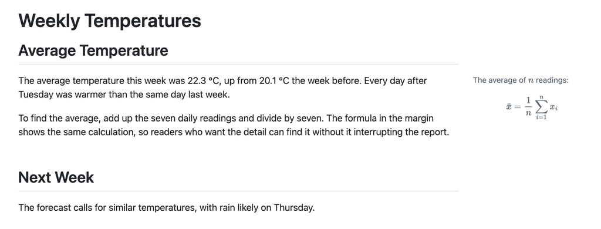

Quarto 網頁：主文欄是兩段關於本週平均氣溫的文字，右側邊欄是灰色小字 The average of n readings 與平均數公式

這裡用到 Quarto 的數學語法：在錢字號之間寫 LaTeX 記號。**兩側各一個 `$`**（如 `$n$`）把數學放在句子內；**兩側各兩個 `$$`**（如上面的 `$$` 行）讓公式獨立成行。公式不只能放邊欄，在文件任何地方、任何格式都能用。

更多版面選項

邊欄只是 Quarto「文章版面（article layout）」的一部分。你也可以把圖說放邊欄，或讓寬表格、寬圖延伸到整個頁面寬度。準備好時看官網 [Article Layout](https://quarto.org/docs/authoring/article-layout.html)。原課程的模擬器不顯示邊欄，請在自己的電腦上試。

小測：想讓公式放在使用它的那段文字旁邊的邊欄，要用 `::: {.column-margin}` 包住（不是公式後加 `{#margin}`，也不是 `::: {.callout-note}`）。

大括號 `{}` 裡能放什麼

你已經看過 `{}` 內能放的三種東西：**ID**（如 `#tbl-sales`）、**class**（如 `.column-margin`）、**屬性**（如 `fig-alt="..."`）。同時用多種時，順序是：先 ID、再 class、最後屬性。

#### 練習：加 callout 與交叉參照

下面這份報告需要兩個收尾：

````
---
title: "Weekly Temperatures"
---

The chart below shows the temperature rising through the week.

Readings from Sunday are estimates.

```{r}
#| label: fig-temps
#| fig-cap: "Daily temperatures"
#| echo: false
temps <- c(18, 21, 24, 19, 23, 26, 25)
plot(temps, type = "b", xlab = "Day", ylab = "Temperature (°C)")
```
````

**動手試：**

1. 把 `The chart below` 這幾個字換成對圖的交叉參照（格子已標為 `fig-temps`）。
2. 把句子 `Readings from Sunday are estimates.` 放進 **warning** callout。

提示：交叉參照是 `@` 加標籤，即 `@fig-temps`；warning callout 以單獨一行的 `::: {.callout-warning}` 開頭、以單獨一行的 `:::` 結尾，句子放中間。

**參考答案：**

````
---
title: "Weekly Temperatures"
---

@fig-temps shows the temperature rising through the week.

::: {.callout-warning}
Readings from Sunday are estimates.
:::

```{r}
#| label: fig-temps
#| fig-cap: "Daily temperatures"
#| echo: false
temps <- c(18, 21, 24, 19, 23, 26, 25)
plot(temps, type = "b", xlab = "Day", ylab = "Temperature (°C)")
```
````

### 關鍵詞

- **callout**：彩色提示框；類型 `note`、`tip`、`important`、`warning`、`caution`。
- **fenced div**：以 `:::` 包住內容的語法，callout 與邊欄都屬於這一類。
- **cross-reference（交叉參照）**：用 `@標籤` 引用圖、表等，由 Quarto 自動編號。
- **標籤前綴**：`fig-` 圖、`tbl-` 表、`sec-` 章節、`eq-` 公式。
- **`.column-margin`**：把內容放進 HTML 頁面右側邊欄的 class。
- **`$` / `$$`**：行內數學／獨立成行的公式（LaTeX 記號）。

### 可執行要點

- 用 `::: {.callout-warning}` 標示一則重要警語，並試著加 `##` 標題
- 替某張圖加 `#| label: fig-xxx`，並在文字中用 `@fig-xxx` 參照
- 寫一個 markdown 表格，加上 `: 圖說 {#tbl-xxx}` 並參照它
- 把一個公式放進 `::: {.column-margin}`（需在自己電腦預覽 HTML）
- 記住 `{}` 內順序：ID → class → 屬性

📝 隨堂測驗（點選項作答）

圖的格子有 `#| label: fig-sales`，文字中要怎麼參照它？

交叉參照就是 @ 加標籤；手寫 Figure 1 不會自動更新編號。

想讓一個公式出現在使用它的段落旁邊的邊欄，要用什麼包住它？

.column-margin 這個 fenced div 會把內容放在 HTML 頁面右側邊欄。

markdown 表格破折號列中的 `------:` 結尾冒號表示什麼？

冒號在破折號右側表示靠右對齊，適合數字欄。

表格要能被 `@tbl-sales` 參照，需要在表格下方做什麼？

以 : 開頭的行是圖說，大括號內的 #tbl-sales 就是標籤。

### 在自己的電腦上使用 Quarto（Using Quarto on Your Own Computer）

Quarto 入門 · 第 7 單元 · 約 15 分

一句話總結

Positron 與 RStudio 都內建 Quarto；**Preview 按鈕**其實是在終端機執行 `quarto preview` 的捷徑，且在一個全新的 session 中跑整份文件，因此文件需要的套件與資料都必須寫在文件自己的格子裡，再用改 `format` 或 `quarto render` 產出 Word、PDF 等格式。

你會學到

- 如何在自己的電腦取得 Quarto
- 如何在 Positron 建立並預覽 Quarto 文件
- Preview 背後執行了什麼，以及 `quarto preview`、`quarto render` 指令
- 為什麼在 Console 跑得動的程式碼，預覽時卻可能失敗
- 如何渲染成 Word、PDF 等其他格式

想跟著做？

如果要在自己電腦上練習、還沒有 Positron，可從 positron.posit.co/download.html 免費下載。

### 內容筆記

#### 取得 Quarto

你在模擬器裡練過的一切，在自己電腦上做法相同。Quarto 是一個負責渲染文件的**命令列程式**。最簡單的取得方式，是用已內建它的編輯器，所以不必另外安裝：

| 編輯器 | 說明 |
| --- | --- |
| **Positron** | 內建 Quarto，並附 Quarto 擴充功能：Preview 按鈕、語法上色、YAML 選項建議 |
| **RStudio** | 也內建 Quarto，編輯器工具列有 Render 按鈕 |
| **其他編輯器** | 從 [quarto.org](https://quarto.org/docs/get-started/) 下載 Quarto；若編輯器有 Quarto 擴充（如 VS Code）再安裝擴充 |

本課以 Positron 示範。若要讓 R 或 Python 程式碼格能執行，還需要安裝 R 或 Python，以及 R 的 `rmarkdown` 套件或 Python 的 `jupyter` 套件。只有文字與 markdown 的文件則不需要其他東西。

#### 建立並預覽文件

建立文件並預覽只要幾次點擊。原課程是點擊截圖的互動模擬，這裡依序展開四步：

**步驟 1：開新檔案。** 點 Positron 左上角的 **New** 按鈕（旁邊是 Open 按鈕；此時 Console 是空的 Python 控制台）。

**步驟 2：** 打開的 New 選單有 New File、New Folder from Template、New Folder from Git、New Window 等項目，點 **New File...**。

**步驟 3：選檔案類型。** Positron 問你要哪種檔案，清單有 Text File、R File、Python File、Jupyter Notebook、Quarto Document、Quarto Project，選 **Quarto Document**。

[figure not shown]

New File 選單：列出 Text File、R File、Python File、Jupyter Notebook、Quarto Document、Quarto Project 六種類型

**步驟 4：預覽。** 文件在編輯器中開啟後，點編輯器左上方的 **Preview**。

你的新文件會更空

在 Positron 建立 Quarto 文件時，一開始只有 YAML 標頭：一個 title 與 `format: html`。原課程模擬中的文件另外加了標題、文字與一個程式碼格，讓預覽有東西可看。

模擬中的文件內容如下（在你自己的 Positron 貼上或自行加入也行）：

````
---
title: "My First Document"
format: html
---

## Hello, Quarto

This document mixes text and code. When you preview it, Quarto
runs the code and shows the result right below it.

```{python}
total = 2 + 3
print(f"The total is {total}")
```
````

[figure not shown]

Positron 編輯器中的新 Quarto 文件：YAML 標頭（title: My First Document、format: html）、## Hello, Quarto 標題、一句說明文字、Python 程式碼格 total = 2 + 3，編輯器上方有 Preview 按鈕與 Render on Save 核取方塊

**完成後的結果：** Positron 渲染文件，並把結果顯示在 **Viewer 窗格**，緊鄰你的原始檔。程式碼已執行，輸出出現在程式碼下方（內容為「The total is 5」）。你修改原始檔再按 Preview，Viewer 就會更新。

[figure not shown]

Positron 預覽結果：一側是 first-qmd.qmd 原始碼，另一側的 Viewer 窗格顯示渲染後的標題 My First Document、Hello, Quarto、程式碼與輸出 The total is 5，下方 Terminal 顯示 quarto preview 指令

用鍵盤預覽

在 Positron 按 **Ctrl/Cmd + Shift + K** 即可預覽，不必動滑鼠。**先把文件存成 `.qmd`**，輸出檔才有地方放。

#### 試試更有趣的文件

想預覽更豐富的內容？把下面其中一份複製進新的 Quarto 文件，存成 `temps.qmd`，按 **Preview**。它用到 callout、交叉參照與程式碼格畫的圖，都是本課練習過的東西。

**R 版**（需要 `rmarkdown` 套件）：

````
---
title: "Weekly Temperatures"
format: html
---

## Summary

The daily highs for the week are in @fig-temps. The warmest reading was **26 °C**.

::: {.callout-note}
Readings from Sunday are estimates.
:::

```{r}
#| label: fig-temps
#| fig-cap: "Daily high temperatures"
#| echo: false
temps <- c(18, 21, 24, 19, 23, 26, 25)
plot(temps, type = "b", xlab = "Day", ylab = "Temperature (°C)")
```
````

**Python 版**（需要 `jupyter` 與 `matplotlib` 套件）：

````
---
title: "Weekly Temperatures"
format: html
---

## Summary

The daily highs for the week are in @fig-temps. The warmest reading was **26 °C**.

::: {.callout-note}
Readings from Sunday are estimates.
:::

```{python}
#| label: fig-temps
#| fig-cap: "Daily high temperatures"
#| echo: false
import matplotlib.pyplot as plt

temps = [18, 21, 24, 19, 23, 26, 25]
plt.plot(range(1, 8), temps, marker="o")
plt.xlabel("Day")
plt.ylabel("Temperature (°C)")
plt.show()
```
````

日常工作流程的正確順序（原課程為排序題）：

1. 建立新的 Quarto 文件並存成 `.qmd`
2. 寫文字與程式碼
3. 按 Preview
4. 在 Viewer 窗格檢查結果

#### 從終端機使用 Quarto

回頭看剛才模擬的最後一個畫面：當你按 **Preview**，Positron 會在底部打開 **Terminal** 分頁並執行類似下面的指令：

```
quarto preview first-qmd.qmd --no-browser --no-watch-inputs
```

Preview 按鈕其實就是 `quarto preview` 指令的捷徑，外加兩個選項：

- `--no-browser`：讓結果顯示在 Positron 的 Viewer 窗格，而不是開啟網頁瀏覽器。
- `--no-watch-inputs`：不要每次存檔就重新渲染，Viewer 只在你再按 **Preview** 時才更新。如果你希望每次存檔都更新，勾選 Preview 旁的 **Render on Save**。

你也可以在任何終端機自己輸入 Quarto 指令，搭配任何編輯器都能用：

```
# Render and open a live preview that updates when you save
quarto preview report.qmd

# Render to the format(s) in the YAML header
quarto render report.qmd

# Render to a specific format
quarto render report.qmd --to docx
```

是 Terminal，不是 Console

Quarto 指令要在 **Terminal**（終端機）輸入，**不是** R 或 Python 的 **Console**。Console 只懂 R 或 Python 程式碼，在那裡打 `quarto render` 會報錯。在 Positron，Terminal 是底部面板的一個分頁，就在 Console 旁邊。

preview 與 render 的分工

`quarto preview` 用於**寫作**：它持續執行，你自己在終端機輸入時，每次存檔都會刷新輸出。`quarto render` 用於**完稿**：產出最終檔案後就結束。

#### Run Cell 與 Preview 的差別

在 Positron，每個程式碼格上方都有 **Run Cell** 連結，寫作時很方便：不必等整份文件，可以一次試一個格子。但 Run Cell 與 Preview 在**不同的地方**執行你的程式碼，**彼此不共用結果**。Run Cell 把程式碼送到 Console；Preview 則在 Terminal 執行 `quarto preview`，那是另一個獨立程式、會開啟自己的 session。

|  | Run Cell | Preview |
| --- | --- | --- |
| **程式碼在哪裡執行** | Console，也就是你的互動式 session | 全新的 session，與 Console 分開 |
| **執行什麼** | 只有那個格子 | 每個格子，由上到下依序 |
| **能用到什麼** | 你到目前為止在 Console 建立的任何東西 | 只有文件本身建立的東西 |

這造成一個經典的意外。假設你在 Console 探索，並在那裡載入資料：

```
import pandas as pd
sales = pd.read_csv("sales.csv")
```

文件中有一個格子是 `sales.head()`。你按 Run Cell 成功了，因為 `sales` 存在於 Console。然後你按 Preview，卻失敗並出現 `NameError: name 'sales' is not defined`。因為 Preview 的全新 session 從沒看過你的 Console，所以那裡沒有 `sales`。R 也一樣，錯誤訊息類似 `object 'sales' not found`。

一切都放在文件裡

文件用到的每個套件、每份載入的資料，都必須寫在文件的某個格子裡，且位置在使用它們的格子**之前**。Preview 才是真正的考驗：它能跑，別人渲染你的文件也就能跑。

小測：Run Cell 成功、Preview 卻說 `model` 沒定義，最可能的原因是你在 Console 建立了 `model`，但文件中沒有任何格子建立它（不是沒存檔，也不是 Preview 不能跑程式碼格）。

#### 渲染成其他格式

在自己的電腦上，Quarto 能產出所有格式，不只 HTML。要切換，就像在模擬器那樣，改 YAML 標頭的 `format`：

```
---
title: "Quarterly Sales Report"
format: docx
---
```

預覽後，Quarto 會在 `.qmd` 旁邊寫出 `report.docx`。HTML 與 PDF 的預覽在 Viewer 窗格開啟；Word 這類格式則在它自己的應用程式中開啟。

若文件在 `format` 下列了**多個**格式，Preview 只會顯示第一個。Positron 有兩個命令處理其他格式。用 Ctrl/Cmd + Shift + P 打開 Command Palette（命令面板）執行：

| 命令 | 作用 |
| --- | --- |
| **Quarto: Preview Format…** | 選一個格式預覽，如 PDF 或 Word |
| **Quarto: Render Document** | 一次渲染文件中的所有格式 |

和 Preview 一樣，它們會替你在 Terminal 執行 Quarto；例如 **Quarto: Render Document** 執行的就是 `quarto render`。

做 PDF

要 PDF 就用 `format: typst`。Typst 隨 Quarto 附帶，不必安裝其他東西，PDF 也會像 HTML 預覽一樣在 Viewer 窗格打開。

小測：文件在 `format` 下同時列了 `html` 與 `docx`，按 Preview 只得到 HTML，要怎麼同時拿到 Word 檔？從 Command Palette 執行 **Quarto: Render Document**（再按一次 Preview 或把檔案存成 `.docx` 副檔名都沒有用）。

### 關鍵詞

- **Positron**：Posit 的編輯器，內建 Quarto 與 Quarto 擴充功能。
- **Preview**：按鈕，等於在 Terminal 執行 `quarto preview`（加 `--no-browser --no-watch-inputs`）。
- **Viewer 窗格**：Positron 中顯示預覽結果的區域。
- **`quarto preview`**：寫作用，持續執行並在存檔時刷新。
- **`quarto render`**：完稿用，產出最終檔後結束；可加 `--to docx` 指定格式。
- **Terminal vs Console**：Quarto 指令只能在 Terminal；Console 只懂 R／Python。
- **Run Cell**：把單一格子送到 Console 執行；與 Preview 的 session 不共用。
- **Command Palette**：Ctrl/Cmd + Shift + P，執行 Quarto: Preview Format… 或 Quarto: Render Document。

### 可執行要點

- 安裝 Positron（或確認 RStudio 內建 Quarto 可用）
- 建立 `New > New File... > Quarto Document`，存成 `.qmd` 後按 Preview（或 Ctrl/Cmd + Shift + K）
- 把 `temps.qmd` 範例貼進去，確認圖與 callout 出現
- 把所有 `library()`／`import` 與資料讀取都寫進文件的格子，並放在使用前
- 以 Preview 作為「文件是否自足」的最終檢查
- 需要 Word／PDF：改 `format`，多格式時用 Quarto: Render Document；PDF 先用 `typst`

📝 隨堂測驗（點選項作答）

Quarto 指令（如 quarto render）應該輸入在哪裡？

Console 只懂 R／Python 程式碼，輸入 quarto render 會出錯；要在 Terminal。

Run Cell 成功、按 Preview 卻說 model 沒定義，最可能的原因？

Preview 在全新 session 從頭執行整份文件，不會用到 Console 裡的東西。

文件的 format 下列了 html 與 docx，按 Preview 只出現 HTML，要同時產出 Word 檔該怎麼做？

Preview 只顯示第一個格式；Quarto: Render Document 會渲染所有格式（等同 quarto render）。

`quarto preview` 與 `quarto render` 的分工是？

preview 持續執行並在存檔時刷新；render 產出最終檔案後就停止。

### 課程總複習（Course Wrap-Up）

Quarto 入門 · 第 8 單元 · 約 8 分

一句話總結

一份 Quarto 文件 = **YAML 標頭 + markdown 文字 + 程式碼格**，在 Positron 或終端機渲染成 HTML、PDF、Word、簡報等；本頁把全課語法濃縮成一頁速查表，並給出後續練習方向。

你會學到

- 全課重點回顧（單元 1–7）
- 一頁式 Quarto 語法速查：YAML、Markdown、程式碼格、Quarto 功能、渲染方式
- 用自己的 `.qmd` 做綜合練習，以及下一步該做什麼

### 內容筆記

#### 你學過的內容

- Quarto 是什麼、渲染如何把 `.qmd` 變成成品，以及它如何從 R Markdown 發展而來
- Quarto 文件的三個部分：YAML 標頭、markdown 文字、程式碼格
- 如何用 markdown 排版文字，並用 YAML 選項與輸出格式控制文件
- 如何加入 R 與 Python 程式碼格，並用格選項控制輸出
- 如何使用 callout、交叉參照、表格與邊欄內容
- 如何在 Positron 與終端機中建立、預覽與渲染文件

更深入或本課未涵蓋的功能，請查 [Quarto 官方文件](https://quarto.org/docs/guide/)。

#### Quarto 速查表

**YAML 標頭**（單元 4）

```
---
title: "Report Title"
author: "Your Name"
date: today
format:
  html:
    number-sections: true
  docx: default
execute:
  echo: false
---
```

**Markdown**（單元 3）

```
## Section heading

**bold**, *italic*, `code`

- Bulleted item
1. Numbered item

[Link text](https://quarto.org)
![Caption](image.png){fig-alt="Description for screen readers"}
```

**程式碼格**（單元 5）

````
```{r}
#| label: fig-sales
#| fig-cap: "Monthly sales"
#| echo: false
plot(sales)
```
````

| 選項 | 效果 |
| --- | --- |
| `echo: false` | 隱藏程式碼，顯示結果 |
| `eval: false` | 顯示程式碼，不執行 |
| `include: false` | 執行程式碼，什麼都不顯示 |

**Quarto 功能**（單元 6）

```
::: {.callout-tip}
A callout: note, tip, important, warning, or caution.
:::

@fig-sales shows the trend.

| Region | Sales |
|--------|------:|
| North  |   120 |

: Sales by region {#tbl-sales}
```

**渲染方式**（單元 7）

| 在哪裡 | 怎麼做 |
| --- | --- |
| Positron | **Preview** 按鈕，或 Ctrl/Cmd + Shift + K |
| Positron，所有格式 | Command Palette 的 **Quarto: Render Document** |
| Terminal | `quarto preview file.qmd` 或 `quarto render file.qmd --to docx` |
| PDF | `format: typst`，不必另外安裝任何東西 |

#### 綜合練習（Keep Practising）

原課程最後提供一個自由練習場。請你在自己的 `.qmd` 貼上下面的起點，試著把學過的全部組合起來：**一個標題、幾個編號章節、一個 callout、以及一張有圖說並用交叉參照引用的圖**。

```
---
title: "My Quarto Document"
author: "Your Name"
format:
  html:
    number-sections: true
---

## Introduction

Write something here.
```

預期結果：渲染後章節標題自動編號；你加入的 callout 以彩色方框顯示；`@fig-xxx` 變成「Figure 1」連結，圖下方有「Figure 1: 圖說」。

#### 下一步（Next Steps）

- **動手做真的：** 打開 Positron，建立 Quarto 文件，寫下你現在正在處理的東西
- **讀官方指南：** [Quarto Guide](https://quarto.org/docs/guide/) 更深入地涵蓋本課每項功能，還有更多
- **找靈感：** [Quarto Gallery](https://quarto.org/docs/gallery/) 有文件、簡報、網站、書籍、儀表板的範例與原始碼
- **試新格式：** 把 `format: html` 改成 `revealjs`，把文件變成投影片

### 關鍵詞

- **`.qmd`**：Quarto 原始檔。
- **YAML 標頭**：`---` 之間的 `key: value` 設定。
- **程式碼格／格選項**：`` ```{r} `` 區塊與 `#|` 設定行。
- **callout / 交叉參照 / 邊欄**：`::: {.callout-}`、`@fig-`／`@tbl-*`、`::: {.column-margin}`。
- **render / preview**：完稿 vs 寫作時的預覽。

### 可執行要點

- 用速查表自己寫一份含 YAML、markdown、程式碼格、callout、交叉參照的 `.qmd`
- 把你手邊真實的分析包成一份 Quarto 文件並 Preview
- 把 `format: html` 改成 `revealjs` 看看簡報效果
- 逛 Quarto Gallery，挑一個想模仿的範例

📝 隨堂測驗（點選項作答）

下列哪一項屬於 Quarto 文件的三個組成部分之一？

三部分是 YAML 標頭、markdown 文字、程式碼格；Console 與 Viewer 屬於編輯器環境。

想隱藏程式碼但顯示結果、且只針對單一格子，要用？

echo: false 寫在格內（以 #| 開頭）可逐格控制；寫在 execute: 下則是整份文件。

要把文件變成簡報，最簡單的做法？

只要改 format（如 revealjs），同一份原始檔就能產生簡報。

📗

## Positron 入門①介面導覽（28 分）

· 6 篇

**🗺️ 本課地圖（點單元標題可跳到那一篇）**

| Positron 是什麼？（What is Positron?） | **Positron 是 Posit 新一代的資料科學 IDE：同一個環境原生支援 Python 與 R，建立在與 VS Code 相同的開源核心（Code OSS）上，同時把 RStudio 熟悉的 Console、Plots、Variables 等資料科學工具內建進來。** |
| --- | --- |
| Positron 的介面配置（The Positron Layout） | **Positron 視窗可分成四個區域——Manage（管理）、Write（撰寫）、Run（執行）、Understand（理解）——對應「管理專案 → 寫程式 → 執行 → 看結果」的工作流程，而最值得先學的捷徑是 Command Palette（`Cmd/Ctrl+Shift+P`）。** |
| 核心面板與區域（Core Panes & Areas） | **Activity bar 決定左側 side bar 顯示什麼；編輯器是「寫」、Console 是「跑」（`Cmd/Ctrl+Enter` 把程式送進 Console）；右側面板用 Session（Variables＋Plots）、Help、History、Viewer 四個分頁收納資料科學工具。** |
| Extensions、主題與快捷鍵（Extensions, Themes & Shortcuts） | **Extensions 從 Extensions 檢視安裝（預設來源是 P3M），主題與設定幾乎都能透過 Command Palette 達成；從 RStudio 轉來的人只要打開 `workbench.keybindings.rstudioKeybindings` 並重啟，就能沿用熟悉的快捷鍵，版面亂了也能一鍵重置。** |
| Interpreter 選擇與 Sessions（Interpreter Selection & Sessions） | **Interpreter 是執行程式的語言與版本，session 是它的一個執行實例，並在你重啟之前一直保存變數、已載入套件與歷史；重啟可得乾淨起點（但會清空記憶體），而 Positron 可同時開多個 session，Python 與 R 並行。** |
| 課程總複習（Course Recap） | **這門課教你在 Positron 裡「找得到東西」：它是 Python 與 R 並行的資料科學 IDE，視窗分成 Manage／Write／Run／Understand 四區，並能用 extensions、主題、快捷鍵、版面與多個 session 調成自己的工作方式。** |

### Positron 是什麼？（What is Positron?）

Positron 入門①介面導覽 · 第 1 單元

一句話總結

**Positron 是 Posit 新一代的資料科學 IDE：同一個環境原生支援 Python 與 R，建立在與 VS Code 相同的開源核心（Code OSS）上，同時把 RStudio 熟悉的 Console、Plots、Variables 等資料科學工具內建進來。**

你會學到

- Positron 是什麼、適合誰用
- Positron 背後的設計理念（四個關鍵字）
- Positron 與 RStudio、VS Code 的關係與差異

想邊讀邊操作？

還沒安裝 Positron 的話，可以到 https://positron.posit.co/download.html 免費下載。

### 內容筆記

#### Positron 是什麼

Positron 是 Posit 的「次世代」資料科學 IDE：**單一、多語言（polyglot）的環境，同時處理 Python 與 R，並建立在開源基礎之上。**

用過 RStudio 的人會覺得大部分地方很熟悉：Console（主控台）、Plots（圖表）、Variables（變數）、資料檢視，都在預期的位置。差別在於 Positron 把 Python 與 R 視為「平等公民」，並且採用與 VS Code 同一套開源基礎，因此彈性大、能隨你的需求成長。

[figure not shown]

Positron 的 Welcome 畫面：最左是活動列與 Explorer 側邊欄（尚未開啟資料夾），中間是 Welcome 分頁（Open Folder、New Folder、New from Git 等入口），下方是已啟動 R 4.5.3 的 Console，最右是 Session 分頁中的 Variables 與 Plots 區塊

這張是剛開啟 Positron 時的畫面：最左是 Explorer，中間是 Welcome 分頁與下方的 Console，最右是 Variables 與 Plots 區。

#### 設計理念：四個關鍵字

| 關鍵字 | 意思 |
| --- | --- |
| **Polyglot（多語言）** | Python 與 R 都是一等公民，換語言不必換工具 |
| **Open foundation（開源基礎）** | 建立在 Code OSS（VS Code 的開源核心）上，可擴充且介面熟悉 |
| **Data science first（資料科學優先）** | Plots、Variables 與資料工具是內建的，不是後來外掛硬湊的 |
| **Flexible（彈性）** | 可重新排列面板、加裝 extensions，把工作區塑造成自己慣用的樣子 |

補充說明

「Polyglot」只是指 Positron 會說不只一種語言。你可以同時開著一個 R 專案與一個 Python 專案，在同一個視窗裡來回切換。

#### 與 RStudio、VS Code 的關係

Positron 位在兩者之間：借用 RStudio 的資料科學使用體驗，加上 VS Code 靈活、可擴充的基礎。

|  | RStudio | VS Code | Positron |
| --- | --- | --- | --- |
| 主要定位 | R（也支援部分 Python） | 通用程式開發 | Python 與 R 的資料科學 |
| 內建資料工具 | 有（plots、environment、viewer） | 沒有（靠 extensions 補） | 有（plots、variables、viewer、Data Explorer） |
| 底層基礎 | 專為 RStudio 打造 | Code OSS | Code OSS |
| Extensions 來源 | 有限 | Visual Studio Marketplace | Posit Public Package Manager（P3M） |

怎麼定位

- 從 RStudio 轉來：把 Positron 想成「你的資料科學工具，搬到更彈性、更現代的基礎上」。
- 從 VS Code 轉來：把 Positron 想成「內建資料科學功能的 VS Code」。

### 關鍵詞

- **Positron**：Posit 的次世代、多語言資料科學 IDE。
- **IDE**：整合開發環境，把編輯器、主控台、圖表、檔案管理放在同一個視窗。
- **Polyglot**：多語言；此處指同時支援 Python 與 R。
- **Code OSS**：VS Code 背後的開源核心，Positron 與 VS Code 共用。
- **P3M（Posit Public Package Manager）**：Positron 預設的 extensions 來源（第 4 單元詳述）。
- **Data Explorer**：Positron 內建的資料檢視工具（原文僅列名稱，用法本單元未說明）。

📝 隨堂測驗（點選項作答）

下列何者最能描述 Positron？

Positron 是 IDE（開發環境），不是雲端服務、套件管理器，更不是新語言。

下列關於 Positron 的敘述，哪一項正確？

Plots、Variables 等資料科學工具是內建的；Positron 可本機安裝，且 Python 與 R 都是一等公民。

和 VS Code 比較，Positron 最大的差異是？

兩者同為 Code OSS 基礎；Positron 的差異在於把資料科學工具內建，且 extensions 預設來自 P3M。

### 可執行要點

- 到 positron.posit.co/download.html 下載並安裝 Positron
- 開啟後辨認出 Console、Variables、Plots 的位置，確認和 RStudio 的習慣差不多
- 記住定位：RStudio 的資料科學體驗 + VS Code 的彈性基礎

### Positron 的介面配置（The Positron Layout）

Positron 入門①介面導覽 · 第 2 單元

一句話總結

**Positron 視窗可分成四個區域——Manage（管理）、Write（撰寫）、Run（執行）、Understand（理解）——對應「管理專案 → 寫程式 → 執行 → 看結果」的工作流程，而最值得先學的捷徑是 Command Palette（`Cmd/Ctrl+Shift+P`）。**

你會學到

- 四個主要區域各是什麼、預設在視窗哪個位置
- 每個區域用來做什麼事
- 四個區域如何對應日常工作流程
- 如何顯示／隱藏區域，以及如何用 Command Palette 找任何指令

### 內容筆記

#### 先認識整個視窗

第一次開啟 Positron，畫面看起來很擁擠，但其實只分成四個區域，各自對應工作流程的一環：管理專案、寫程式、執行、理解回傳結果。能叫出這四個名字，後面的課程就容易對上。

[figure not shown]

Positron 視窗被標成四個區域：最左側的 Manage、上方中央的 Write、下方中央的 Run、最右側的 Understand

預設配置是：Manage 在視窗最左側、Write 在中央偏上、Run 在 Write 的正下方、Understand 在最右側。

#### 四個區域

| 區域 | 預設位置 | 對應的介面元件 | 用途 |
| --- | --- | --- | --- |
| **Manage** | 最左側 | Activity bar（活動列）＋ Side bar（側邊欄） | 管理環境：開資料夾、在 Explorer 瀏覽檔案、搜尋、使用 Source Control |
| **Write** | 中央偏上 | Editor（編輯器） | 撰寫：腳本、notebook、文件都以分頁開在這裡，是主要寫作的地方 |
| **Run** | 編輯器正下方 | Console（主控台）與 Terminal（終端機） | 執行：從編輯器送出一行，或直接在 Console 輸入，立刻執行 Python 或 R 並看到結果 |
| **Understand** | 最右側 | 右側一組面板 | 理解：Variables 顯示環境中有什麼、Plots 顯示圖表，另有 Help 與 Viewer |

**Manage**：Activity bar 是視窗最左邊的一條圖示列，緊鄰它的是 Side bar。點選 Activity bar 上的圖示，就會切換 Side bar 顯示的內容。

**Write**：腳本、notebook、文件各以一個分頁開在編輯器裡（例如開著一支 R 腳本 `testing.R`），大部分撰寫工作在這裡完成。

**Run**：位於編輯器下方的面板，上方有一排分頁，包括 Console、Terminal、Problems、Output、Ports、Debug Console。

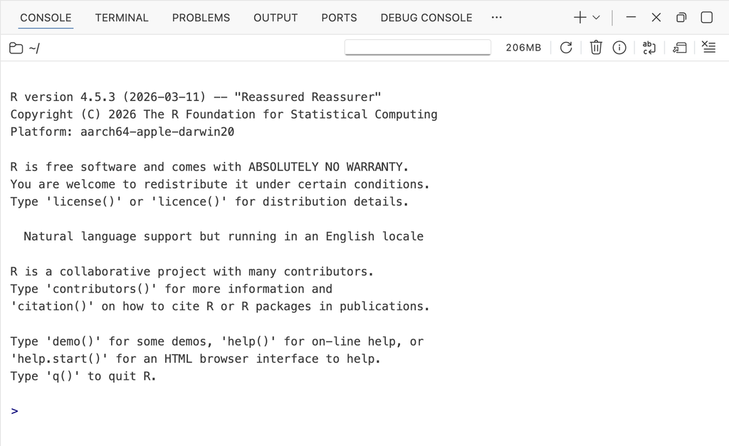

編輯器下方的面板：分頁列依序為 CONSOLE、TERMINAL、PROBLEMS、OUTPUT、PORTS、DEBUG CONSOLE；目前停在 CONSOLE，顯示 R 4.5.3 啟動訊息與等待輸入的 > 提示符號

**Understand**：右側面板上方有分頁（Session、Connections、Help、History、Viewer 等，下一單元詳述）；Session 分頁內有 Variables 與 Plots 兩個區塊。

區域只是思考方式

這四區是理解版面的「思考框架」，不是固定的牆。Positron 允許重新排列與調整面板大小，可以依自己的習慣調整（第 4 單元會教）。

#### 區域如何串成工作流程

流程是：在左側**管理**專案 → 在中央**撰寫**程式 → 在正下方**執行** → 在右側**理解**結果。視線大致由左到右、由上到下，每一步的位置都很靠近下一步。

#### 顯示／隱藏任一區域

不必一直開著所有區域。視窗右上角有三個版面切換圖示，可分別開關：左側的 side bar、下方的 panel、右側的 panes。

#### 小練習：這件事屬於哪個區域？

| 任務 | 區域 |
| --- | --- |
| 開啟專案資料夾 | Manage |
| 瀏覽專案檔案 | Manage |
| 檢視 Source Control 的變更 | Manage |
| 編輯 R 腳本 | Write |
| 在分頁開啟 notebook | Write |
| 輸入指令並立刻看結果 | Run |
| 在 Terminal 執行 shell 指令 | Run |
| 查看工作階段中有哪些變數 | Understand |
| 看剛畫好的圖 | Understand |

#### Command Palette（指令面板）

在四個區域之外，做幾乎任何事最快的方法就是 Command Palette：

- 快捷鍵：`Cmd+Shift+P`（macOS）／`Ctrl+Shift+P`（Windows/Linux）
- 或點視窗上方的搜尋列，選 **Show and Run Commands**
- 然後輸入想做的事並執行，不必在選單裡翻找

幾乎所有指令、設定、動作都能從這裡抵達，所以是「第一個值得學的捷徑」。後面課程會用它來切換主題、開啟設定、管理 sessions。

### 關鍵詞

- **Activity bar（活動列）**：視窗最左側的一條圖示列，用來切換 Side bar 內容。
- **Side bar（側邊欄）**：緊鄰 Activity bar，顯示目前選取的檢視（如 Explorer）。
- **Editor（編輯器）**：中央撰寫腳本、notebook、文件的區域。
- **Console / Terminal**：編輯器下方，執行 Python/R 與 shell 指令的地方。
- **Command Palette**：用輸入文字搜尋並執行指令的面板。

📝 隨堂測驗（點選項作答）

你想「看目前環境裡有哪些變數」，應該去哪一區？

Variables、Plots、Help、Viewer 都在 Understand 區（預設位於最右側）。

把 Positron 的四區對應到工作流程，順序是？

管理專案、撰寫程式、執行、理解結果。

想快速找到並執行任何指令，最該先記住哪個快捷鍵？

Cmd/Ctrl+Shift+P 開啟 Command Palette，幾乎所有指令與設定都能從這裡抵達。

### 可執行要點

- 開啟 Positron，指出 Manage、Write、Run、Understand 各在視窗哪個位置
- 練習用視窗右上角的三個圖示顯示／隱藏左側 side bar、下方 panel、右側 panes
- 按 `Cmd+Shift+P`（Mac）或 `Ctrl+Shift+P`（Windows）開啟 Command Palette 並搜尋一個指令

### 核心面板與區域（Core Panes & Areas）

Positron 入門①介面導覽 · 第 3 單元

一句話總結

**Activity bar 決定左側 side bar 顯示什麼；編輯器是「寫」、Console 是「跑」（`Cmd/Ctrl+Enter` 把程式送進 Console）；右側面板用 Session（Variables＋Plots）、Help、History、Viewer 四個分頁收納資料科學工具。**

你會學到

- 如何使用 Activity bar 與 Primary side bar
- 編輯器與 Console 的用途與差別
- 右側各資料面板（Session、Help、History、Viewer）各做什麼

### 內容筆記

#### Activity bar 與 Primary side bar

Activity bar 預設是視窗最左側一條垂直的圖示列。每個圖示會在緊鄰的 Primary side bar 開啟不同的檢視；點圖示，側邊欄內容就跟著切換。

| 圖示名稱 | 開啟的檢視 | 用途 |
| --- | --- | --- |
| Explorer | 檔案樹 | 瀏覽並開啟專案中的檔案 |
| Search | 搜尋檢視 | 在整個專案中搜尋與取代文字 |
| Source Control | Git 檢視 | 用 Git 進行 stage、commit、檢視變更 |
| Run and Debug | 偵錯檢視 | 執行程式並以中斷點逐步除錯 |
| Extensions | Extensions 檢視 | 瀏覽並安裝擴充功能 |
| Packages | Packages 檢視 | 瀏覽、安裝、更新、移除 Python 與 R 套件 |
| Posit Assistant | Posit Assistant 對話 | 與內建 AI 助理 Posit Assistant 討論你的程式碼 |
| Data Connections | Data Connections 檢視 | 儲存資料庫連線、瀏覽資料表、在 Data Explorer 預覽，並用 **Connect With** 產生連線程式碼 |

騰出編輯空間

再點一次「目前選取中」的圖示就會收起 side bar，給編輯器更多空間；點任一圖示即可叫回來。

Data Connections 是預覽功能

要先選擇啟用，圖示才會出現：開啟 Settings，搜尋 `dataConnections.enabled`，勾選後重新載入 Positron。

#### 編輯器與 Console：寫 vs. 跑

兩者初學容易混淆，要點是：**編輯器用來「寫」程式，Console 用來「執行」程式。**

|  | Editor（編輯器） | Console（主控台） |
| --- | --- | --- |
| 角色 | 寫程式的地方 | 執行程式的地方 |
| 內容 | 以分頁開啟腳本、notebook 與其他檔案 | 互動式執行 Python 或 R：輸入一行、按 Enter、立即看到結果 |
| 特性 | 在你「送出」之前不會執行；可分割編輯器並排看兩個檔案 | 很適合快速檢查、探索資料 |

從編輯器執行一行時，那行會被送到 Console 並在那裡執行。把游標放在腳本的某一行，按 **`Cmd+Enter`（macOS）／`Ctrl+Enter`（Windows/Linux）** 即可：

```
# 用 Cmd/Ctrl + Enter 送到 Console 執行
summary(mtcars$mpg)
```

[figure not shown]

（補充）這個「在腳本中逐行執行、結果出現在 Console」的操作，和 RStudio 的 Ctrl+Enter 習慣相同。

Console 跑在特定的 session 上

Console 永遠執行在某個特定的 interpreter session（某個 Python 或 R 版本）中。如何選擇與管理 session，第 5 單元會教。

#### 右側面板：Secondary side bar 的四個分頁

預設在右側的面板是 Positron 資料科學工具的所在，以頂端分頁分組：**Session、Help、History、Viewer**（畫面中還可看到 Connections 分頁，本課未說明）。

| 分頁 | 內容 |
| --- | --- |
| **Session** | 一眼看完整個工作階段：**Variables** 列出環境中的物件（資料框、向量、數值等）；**Plots** 收集你畫出的圖，可瀏覽、放大、匯出 |
| **Help** | 不離開 Positron 就能查文件：搜尋 Python 或 R 說明，並連到 Positron 文件、社群論壇與 Posit cheat sheets |
| **History** | 已執行指令的紀錄。選一條用 **To Console** 重跑，或用 **To Source** 貼進腳本 |
| **Viewer** | 顯示「應用程式或文件型」內容，如渲染後的 Quarto 報告、Shiny 應用，直接在 Positron 內檢視。類圖表輸出（即使可互動）則是顯示在 Plots，而不是 Viewer |

**Session 分頁**：

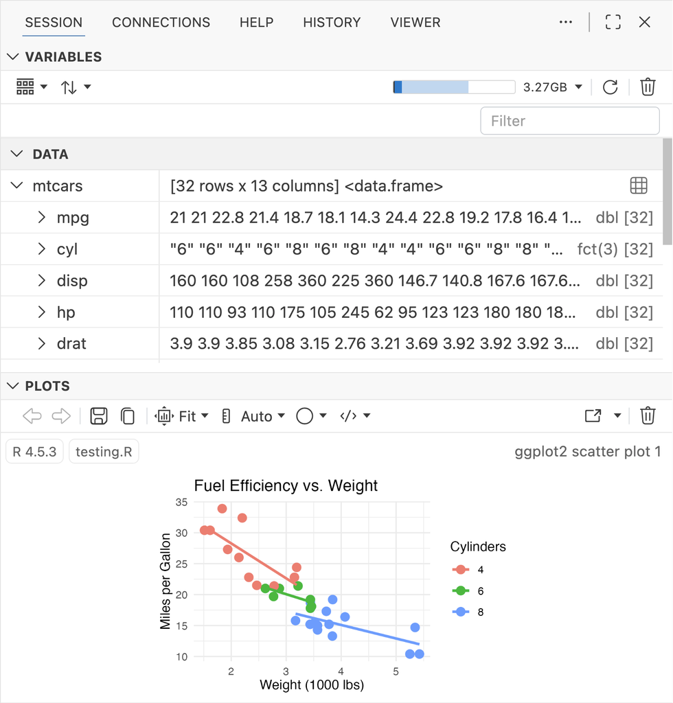

Session 分頁：上方 Variables 區塊列出資料框 mtcars（32 列 × 13 欄）及其欄位 mpg、cyl、disp、hp、drat 的型別與前幾個值；下方 Plots 區塊顯示一張以 ggplot2 畫的「Fuel Efficiency vs. Weight」散布圖，並有儲存、複製、縮放等工具列

**History 分頁**：

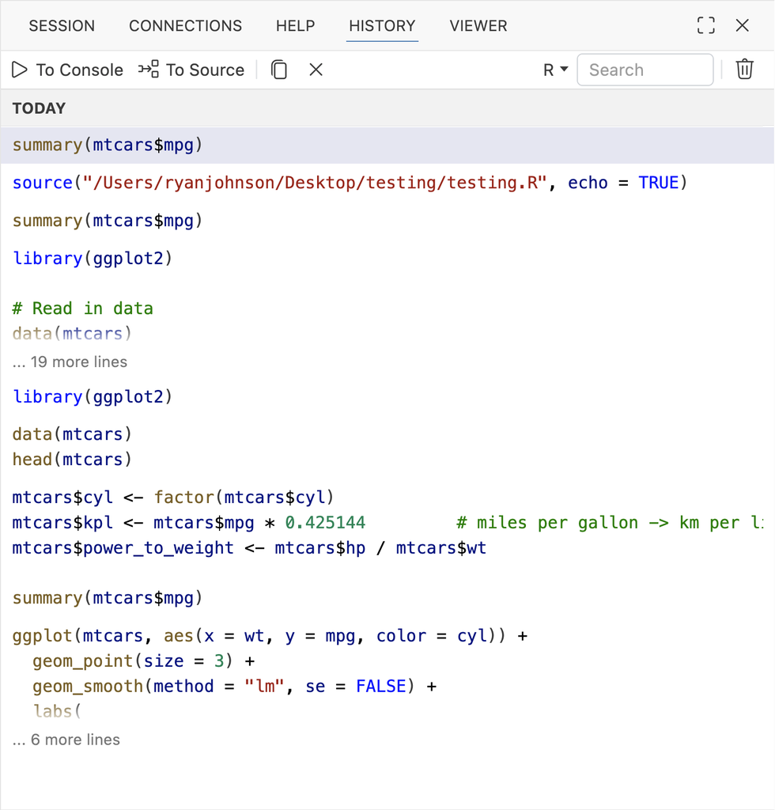

History 分頁：依時間列出先前在 Console 執行過的 R 指令（如 summary(mtcars$mpg)、library(ggplot2)），上方有 To Console 與 To Source 兩個按鈕

**Viewer 分頁**：

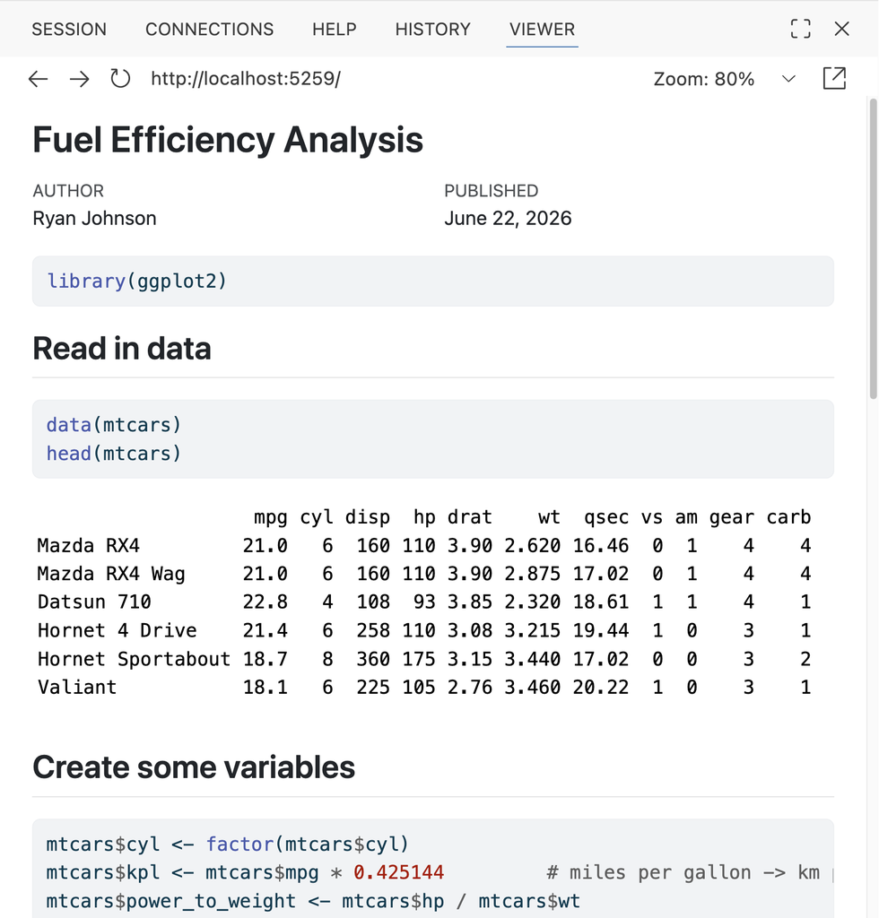

Viewer 分頁顯示一份渲染後的 Quarto HTML 報告「Fuel Efficiency Analysis」，內含 library(ggplot2) 程式碼與 mtcars 資料的前幾列輸出

Help 分頁（內容為 Positron 文件、社群論壇、cheat sheets 的連結）沒有放圖，用文字描述即可。

面板可以拖曳

預設排列不合用時，可把任何面板拖到新位置；下一單元會講如何自訂版面。

（補充）若以 RStudio 對照：Variables 約略對應 Environment 分頁，Plots／Help／Viewer／History 在 RStudio 也有同名面板；Positron 把它們收進同一個右側面板的分頁中。

#### 小練習：分頁配對

| 功能描述 | 分頁 |
| --- | --- |
| 列出變數並收集圖表 | Session |
| 保存你執行過的指令紀錄 | History |
| 顯示渲染後的報告與應用程式 | Viewer |
| 瀏覽 Python 與 R 文件 | Help |

### 關鍵詞

- **Activity bar**：最左側圖示列，切換 Primary side bar 顯示的檢視。
- **Primary side bar**：緊鄰 Activity bar 的側邊欄，顯示 Explorer、Search 等。
- **Secondary side bar**：預設在右側的面板區，含 Session、Help、History、Viewer 分頁。
- **Variables / Plots**：Session 分頁內，分別列出環境物件與收集圖表。
- **To Console / To Source**：History 中，把指令重新執行／貼回腳本。
- **Posit Assistant**：Positron 內建的 AI 助理。

📝 隨堂測驗（點選項作答）

Activity bar（最左側的圖示列）的功能是？

每個圖示對應一種檢視（Explorer、Search、Source Control⋯），點選後側邊欄隨之切換。

從編輯器執行游標所在的那一行，用什麼快捷鍵？

Cmd/Ctrl+Enter 會把該行送到 Console 執行。

想把先前執行過的某條指令重新跑一次，應該用哪個分頁與按鈕？

History 記錄指令；To Console 重跑，To Source 則貼進腳本。

互動式的圖表輸出與渲染後的 Quarto 報告，各會顯示在哪裡？

原文指出類圖表輸出（即使可互動）進 Plots；應用程式／文件型內容（Quarto 報告、Shiny）進 Viewer。

### 可執行要點

- 逐一點 Activity bar 的圖示，確認各自開啟什麼；再點一次作用中圖示試試收起 side bar
- 在腳本寫 `summary(mtcars$mpg)`，按 `Cmd/Ctrl+Enter`，看 Console 輸出
- 打開右側 Session、Help、History、Viewer 四個分頁，各看一次
- 要用 Data Connections 前，先到 Settings 開啟 `dataConnections.enabled` 並重新載入

### Extensions、主題與快捷鍵（Extensions, Themes & Shortcuts）

Positron 入門①介面導覽 · 第 4 單元

一句話總結

**Extensions 從 Extensions 檢視安裝（預設來源是 P3M），主題與設定幾乎都能透過 Command Palette 達成；從 RStudio 轉來的人只要打開 `workbench.keybindings.rstudioKeybindings` 並重啟，就能沿用熟悉的快捷鍵，版面亂了也能一鍵重置。**

你會學到

- Extensions 如何運作、從哪裡來
- 如何更換色彩主題
- 快捷鍵與「RStudio keybindings」設定如何運作
- 如何重新排列並重置面板版面

### 內容筆記

#### Extensions（擴充功能）

Extensions 為 Positron 增加功能，從語言支援、主題到生產力工具都有。到 Activity bar 的 **Extensions** 檢視（圖示像一疊方塊）瀏覽與安裝。

安裝步驟：開啟 Extensions 檢視 → 搜尋想要的 → 在結果上按 **Install**。裝好後該項目會出現齒輪圖示，並列在「已安裝」清單中。

[figure not shown]

Extensions 檢視：頂端是「Search Extensions in Marketplace」搜尋框，下方 INSTALLED 清單（17 個）列出 Air - R Language Support（R 格式化與 language server，Posit Software, PBC 發行）、Black Formatter、GitHub Pull Requests、Jupyter 等，每項右側有齒輪圖示

預設來源：P3M

Positron 預設從 [Posit Public Package Manager（P3M）](https://packagemanager.posit.co/) 安裝 extensions，由 Posit 自己的基礎設施提供，確保穩定散布。其目錄與 [Open VSX](https://open-vsx.org)（Visual Studio Marketplace 的開源、中立替代品）相同。若想直接用 Open VSX，切換 `positron.extensions.gallerySource` 設定即可。

Bootstrapped extensions

有些 extensions 是「bootstrapped」：隨 Positron 附帶、自動幫你裝好。例如 Posit Publisher，因此開箱即可發佈到 Posit Connect。完整清單見 positron.posit.co/extensions.html#bootstrapped-extensions。

#### Color Themes（色彩主題）

Positron 內建多款主題，隨時可切換；選到某個主題時介面顏色立即改變，所以可以先預覽再決定。

內建主題舉例：**Light**（預設）、**Dark**、**Tomorrow Night Blue**、**Light High Contrast**、**Dark High Contrast**。

開啟主題選單有兩種方式：

| 方式 | 步驟 |
| --- | --- |
| Command Palette | 1. 按 `Cmd+Shift+P`（macOS）／`Ctrl+Shift+P`（Windows/Linux）。 2. 輸入 `Color Theme`，選 **Preferences: Color Theme**。 3. 用方向鍵預覽，按 Enter 套用 |
| 選單 | 1. 開啟設定選單（齒輪圖示，通常在左下角）。 2. 選 **Themes** → **Color Theme**。 3. 從清單選一個主題套用 |

#### Keyboard Shortcuts（鍵盤快捷鍵）

從 RStudio 轉來不需要重學所有快捷鍵，Positron 可以把快捷鍵重新對應成你熟悉的。

| 模式 | 說明 |
| --- | --- |
| **Default keybindings** | Positron 預設快捷鍵，與 Code OSS 生態系共用 |
| **RStudio keybindings** | 內建設定（不是 extension），啟用一大批 RStudio 快捷鍵，例如 `Ctrl+1`、`Ctrl+2` 分別聚焦到 Source 與 Console |

**開啟 RStudio keybindings：**

1. 開啟設定：`Cmd+,`（macOS）／`Ctrl+,`（Windows/Linux），或在 Command Palette 執行 **Preferences: Open Settings**。
2. 搜尋 `workbench.keybindings.rstudioKeybindings`，勾選核取方塊。
3. **重新啟動 Positron** 才會生效。

補充說明

完整快捷鍵清單見 positron.posit.co/migrate-rstudio-keybindings.html。即使不啟用此設定，也有少數熟悉的 RStudio 快捷鍵本來就能用。

**檢視或修改單一快捷鍵：** Command Palette 執行 **Preferences: Open Keyboard Shortcuts** → 以名稱搜尋指令（例如 `Run Selection`）→ 雙擊它的快捷鍵 → 按下想指定的新按鍵。

指定新快捷鍵前先檢查衝突

留意「When」欄位與衝突警告。重複使用已被綁定的組合，可能蓋掉你原本依賴的快捷鍵。

設定跟著使用者設定檔走

你的客製化會綁在 user profile 上，下次開啟 Positron 依然保留。

#### 自訂版面（Customizing Your Layout）

面板不是固定死的，可依工作習慣重排，也能隨時回到整齊的起點。

- **預設版面（Preset layouts）**：開 Command Palette，執行 **Customize Layout** 相關指令（搜尋 `layout`），在內建配置間切換，例如以 Posit Assistant 為優先的版面、或適合 notebook 工作的版面。
- **自行移動**：拖曳面板的分頁，停靠到新位置；或在 Activity bar 圖示上按右鍵，隱藏它或改變位置。
- **重置**：版面亂掉時，在 Command Palette 執行 **View: Reset View Locations**，全部恢復預設。

版面也會被記住

與其他客製化一樣，版面變更跟著 user profile，下次開啟會記得。

#### 指令／設定對照

| 指令或設定 | 作用 |
| --- | --- |
| `Preferences: Color Theme` | 預覽並套用色彩主題 |
| `workbench.keybindings.rstudioKeybindings` | 重啟後啟用熟悉的 RStudio 快捷鍵 |
| `Preferences: Open Keyboard Shortcuts` | 檢視並重新指定個別快捷鍵 |
| `View: Reset View Locations` | 把每個面板放回預設位置 |

這些都能從 Command Palette 或 Settings 找到，想改外觀或行為，搜尋一下就到。

### 關鍵詞

- **Extension**：擴充功能，加語言支援、主題、工具。
- **P3M**：Posit Public Package Manager，Positron 預設的 extensions 來源。
- **Open VSX**：開源、中立的 extensions 市集；目錄與 P3M 相同。
- **Bootstrapped extension**：隨 Positron 附帶、自動安裝的 extension（如 Posit Publisher）。
- **RStudio keybindings**：內建設定，啟用一批 RStudio 快捷鍵（需重啟）。
- **User profile**：保存你的設定、快捷鍵與版面的使用者設定檔。

🎴 單字卡（點卡片翻面）

📝 隨堂測驗（點選項作答）

預設情況下，Positron 從哪裡安裝 extensions？

預設是 P3M，其目錄與 Open VSX 相同；要直接用 Open VSX 可改 positron.extensions.gallerySource。

啟用 RStudio keybindings 後，要怎樣才會生效？

勾選 workbench.keybindings.rstudioKeybindings 後必須重啟 Positron。

自訂版面弄亂了，想一鍵恢復預設，該執行？

View: Reset View Locations 會把每個面板放回預設位置。

### 可執行要點

- 開啟 Extensions 檢視，搜尋並安裝一個你需要的 extension
- 用 `Preferences: Color Theme` 預覽並選一個主題
- 若從 RStudio 轉來：Settings 搜尋 `workbench.keybindings.rstudioKeybindings` 勾選並重啟
- 改任何快捷鍵前，先看 When 欄位與衝突警告
- 試著拖曳一個面板，再用 `View: Reset View Locations` 還原

### Interpreter 選擇與 Sessions（Interpreter Selection & Sessions）

Positron 入門①介面導覽 · 第 5 單元

一句話總結

**Interpreter 是執行程式的語言與版本，session 是它的一個執行實例，並在你重啟之前一直保存變數、已載入套件與歷史；重啟可得乾淨起點（但會清空記憶體），而 Positron 可同時開多個 session，Python 與 R 並行。**

你會學到

- 如何選擇 Python 或 R interpreter
- session 是什麼、裡面保存了什麼
- 重啟、切換、同時執行多個 session 的方式

### 內容筆記

#### 選擇 Interpreter

| 名詞 | 意思 |
| --- | --- |
| **Interpreter** | 執行你程式的語言與版本（例如 R 4.5.3 或 Python 3.12） |
| **Session** | 一個 interpreter 的一次執行實例；保存你已執行程式的變數、已載入的套件與歷史，直到你重啟它 |

**interpreter picker（interpreter 選擇器）** 顯示 Console 目前跑的語言與版本，位於視窗上方的 action bar 最右上角，會顯示類似 `R 4.5.3` 或 `Python 3.12`。

操作：點它 → 開啟 Positron 偵測到的 interpreter 清單 → 選你要的 → 指示文字隨之更新。

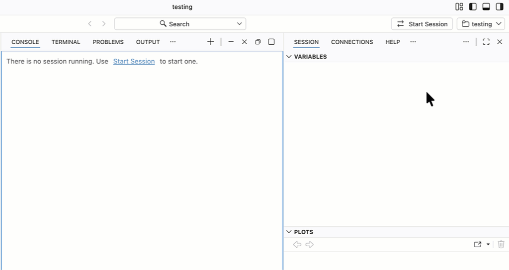

尚未啟動任何 session 時，Console 顯示「There is no session running. Use Start Session to start one.」，視窗右上角有 Start Session 按鈕與資料夾名稱；之後從清單選擇 R 即可啟動

補充說明

若機器上裝了多個 Python 或 R 版本，都會列在這裡；這也是把專案固定在特定版本的方式。若你裝的某個版本沒出現在清單，通常是因為它在非標準位置，Positron 沒偵測到。

#### 重啟與切換 Session

有時想要乾淨的起點，或想同時並排跑 Python 與 R。三種操作：

| 操作 | 作法 |
| --- | --- |
| **Restart（重啟）** | 取得全新的 session，清除所有變數與已載入的套件；可從 Command Palette，或 Console 上的重啟控制項執行 |
| **Start an additional session（另開 session）** | 從 interpreter picker 再啟動一個；Positron 可同時保留多個執行中的 session |
| **Switch（切換）** | 從 Console 的 session 清單選你要的 session |

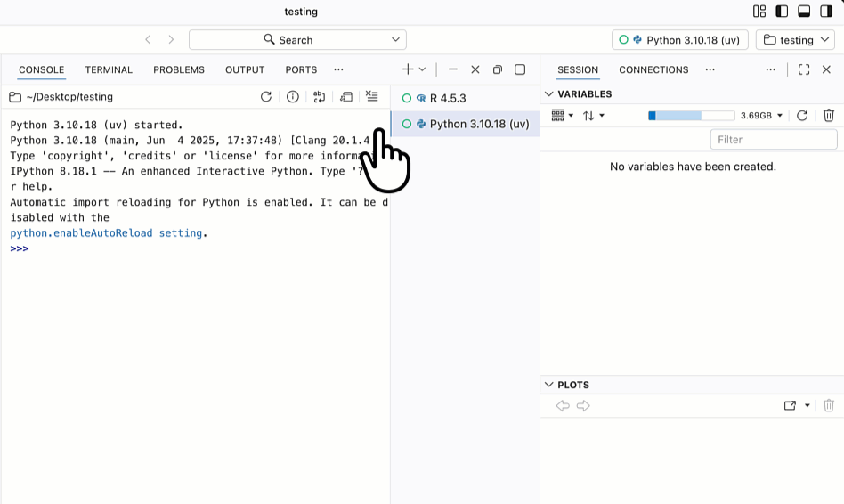

Console 旁的 session 清單同時列出 R 4.5.3 與 Python 3.10.18 (uv) 兩個執行中的 session，目前選中的是 Python；Console 顯示 Python 啟動訊息與 >>> 提示符號

重啟會清空記憶體

重啟 session 會抹掉該 session 在記憶體中的一切：變數、已載入的套件、指令歷史。需要的東西請先存檔。

多語言 IDE 的好處

同時在不同 session 跑 Python 與 R，是多語言 IDE 的一大優點，不必關掉一個才能用另一個。

#### 情境判斷：該用哪一招？

情境：你整個早上都在 R session 做實驗，現在腳本給出的結果和你第一次跑時不同，懷疑是先前實驗留下的變數干擾。

| 選項 | 判斷 |
| --- | --- |
| 換成另一個 R 版本 | 不對。換版本會改變 interpreter 本身，可能帶來新差異；問題在記憶體內容，不在版本 |
| 另開一個 Python session | 不對。Python session 與 R 並行、互不影響，你的 R session 仍有那些殘留變數 |
| **重啟 R session，再從頭跑腳本** | 正確。重啟會清掉記憶體中的變數、套件與歷史，從乾淨狀態重跑才看得出腳本真正的輸出 |

### 關鍵詞

- **Interpreter**：執行程式的語言與版本。
- **Session**：interpreter 的一個執行實例，保存變數、套件、歷史。
- **Interpreter picker**：視窗右上方 action bar 的選擇器，顯示並切換語言版本。
- **Restart**：重啟 session，得到乾淨狀態但清空記憶體。

📝 隨堂測驗（點選項作答）

你懷疑腳本結果被前面實驗留下的變數干擾，最直接的作法是？

重啟會清除變數、已載入套件與歷史，讓你在乾淨狀態重跑。

下列哪一項說法正確？

Positron 支援多個 session 並行；重啟只影響記憶體，與檔案無關；picker 會列出偵測到的所有版本。

Interpreter picker 位在哪裡？

它在上方 action bar 的右上角，顯示類似 R 4.5.3 或 Python 3.12。

### 可執行要點

- 點右上角 interpreter picker，看 Positron 偵測到哪些 R 與 Python 版本
- 另開一個 Python（或 R）session，並在 Console 的 session 清單中切換
- 練習重啟 session；重啟前先確認重要內容已存檔
- 遇到結果怪怪的，先重啟 session、從頭重跑腳本

### 課程總複習（Course Recap）

Positron 入門①介面導覽 · 第 7 單元（總複習；第 6 單元為在 Positron 內的動手實作，本筆記未收錄）

一句話總結

**這門課教你在 Positron 裡「找得到東西」：它是 Python 與 R 並行的資料科學 IDE，視窗分成 Manage／Write／Run／Understand 四區，並能用 extensions、主題、快捷鍵、版面與多個 session 調成自己的工作方式。**

你會學到

- Positron 是什麼，與 RStudio、VS Code 的關係
- 四個區域：Manage、Write、Run、Understand
- Activity bar、編輯器、Console、右側面板各自做什麼
- 如何用 extensions、主題、快捷鍵、版面客製化
- 如何選擇 interpreter 並管理 sessions

### 內容筆記

#### 1. Positron 是什麼（第 1 單元）

Posit 的次世代、多語言（Python + R）資料科學 IDE，建立在與 VS Code 相同的開源核心 Code OSS 上。相較 RStudio：基礎更彈性；相較 VS Code：資料科學工具（plots、variables、viewer、Data Explorer）是內建的。

#### 2. 四個區域（第 2 單元）

| 區域 | 預設位置 | 內容 |
| --- | --- | --- |
| Manage | 最左側 | Activity bar ＋ side bar（Explorer、搜尋、Source Control） |
| Write | 中央偏上 | 編輯器 |
| Run | 編輯器下方 | Console 與 Terminal |
| Understand | 最右側 | Variables、Plots、Help、Viewer |

工作流程：管理 → 撰寫 → 執行 → 理解。視窗右上角三個圖示可顯示／隱藏左側 side bar、下方 panel、右側 panes。

#### 3. 核心面板（第 3 單元）

- Activity bar 切換 side bar 的檢視：Explorer、Search、Source Control、Run and Debug、Extensions、Packages、Posit Assistant、Data Connections（預覽功能，需啟用 `dataConnections.enabled`）。
- 編輯器是「寫」，Console 是「跑」；`Cmd/Ctrl+Enter` 把游標所在行送進 Console。
- 右側分頁：Session（Variables＋Plots）、Help、History（To Console／To Source）、Viewer（Quarto 報告、Shiny 等應用或文件）。

#### 速查表：想做什麼，去哪裡

| 想要⋯ | 使用 |
| --- | --- |
| 開啟資料夾或瀏覽專案檔案 | Activity bar 的 Explorer |
| 寫腳本或 notebook | 中央的編輯器 |
| 執行程式並立刻看結果 | 編輯器下方的 Console |
| 查看變數與圖表 | 右側的 Session 分頁 |
| 不離開 Positron 讀文件 | Help 分頁 |
| 依名稱找任何指令或設定 | Command Palette（`Cmd/Ctrl+Shift+P`） |
| 更換執行的語言與版本 | 右上角的 interpreter picker |

#### 4. 讓它成為你的（第 4 單元）

| 面向 | 重點 |
| --- | --- |
| Extensions | 從 Extensions 檢視安裝，預設來源是 Posit Public Package Manager |
| Themes | 執行 `Preferences: Color Theme`，用方向鍵預覽再決定 |
| Shortcuts | 開啟 `workbench.keybindings.rstudioKeybindings`（重啟生效），或用 `Preferences: Open Keyboard Shortcuts` 重新指定 |
| Layout | 拖曳面板、切換預設版面（搜尋 `layout`）、用 `View: Reset View Locations` 重置 |

#### 5. Interpreter 與 Sessions（第 5 單元）

- Interpreter ＝ 語言＋版本；session ＝ 它的一次執行，保存變數、套件、歷史。
- 右上角 interpreter picker 選擇；可重啟（清空記憶體）、另開 session、在 Console 的 session 清單切換。
- Python 與 R 可並行各跑一個 session。

### 關鍵詞

- **Code OSS**、**Polyglot**、**P3M**、**Command Palette**、**Session / Interpreter**：定義見第 1、2、4、5 單元筆記。

📝 隨堂測驗（點選項作答）

Positron 的四個區域依工作流程順序是？

管理專案 → 撰寫 → 執行 → 理解結果。

想查看目前的變數與圖表，應該看哪裡？

Session 分頁包含 Variables 與 Plots。

從 RStudio 轉來，想沿用熟悉的快捷鍵，該怎麼做？

這是內建設定而非 extension，需重啟才生效。

### 可執行要點

下面是課程建議的後續步驟：

- 用 Positron 開一個自己的專案並從頭跑到尾：開資料夾 → 選 interpreter → 執行腳本 → 檢查 Variables 與 Plots
- 設定成自己慣用的樣子：選主題、（從 RStudio 轉來的話）開 RStudio keybindings、排好面板
- 把官方文件放在手邊：Layout（positron.posit.co/layout.html）、Keyboard shortcuts（positron.posit.co/keyboard-shortcuts.html）、Extensions（positron.posit.co/extensions.html）、Managing interpreters（positron.posit.co/managing-interpreters.html）

📙

## Positron 入門②處理資料（25 分）

· 5 篇

**🗺️ 本課地圖（點單元標題可跳到那一篇）**

| 用 Data Explorer 檢視資料檔（Viewing Data Files with the Data Explorer） | 在 Positron 的檔案樹選一下資料檔，就能用 **Data Explorer** 直接預覽 CSV／Parquet 等表格檔，**不必先寫讀檔程式、也不會動到你的 R／Python session**。 |
| --- | --- |
| 把資料載入 Python 與 R（Loading Data into Python and R） | 用一行標準讀檔指令把檔案讀成 Python／R 物件後，**Variables pane 顯示 session 中的物件與摘要，點資料圖示（或 `%view`／`View()`）即可在 Data Explorer 看完整表格**。 |
| 用 Data Connections 連接資料庫（Connecting to Databases with Data Connections） | 開啟預覽功能 **Data Connections** 後，可把資料庫存成連線、不寫 SQL 就逐層瀏覽表格、在 Data Explorer 預覽，並用 **Connect With** 自動產生 Python／R 連線程式碼。 |
| 分析資料：圖表、表格與 Viewer（Analyzing Data: Plots, Tables, and the Viewer） | 分析輸出去哪由類型決定：**圖（靜態或互動）進 Plots pane、App 與文件型輸出（含 HTML 表格）進 Viewer、純文字列印留在 console**。 |
| 課程總複習（Course Recap） | 在 Positron 處理資料的流程是 **預覽 → 載入 → 連線 → 轉成程式碼 → 分析輸出**，每一步都有對應的內建面板。 |

### 用 Data Explorer 檢視資料檔（Viewing Data Files with the Data Explorer）

Positron 入門②處理資料 · 第 1 單元

一句話總結

在 Positron 的檔案樹選一下資料檔，就能用 **Data Explorer** 直接預覽 CSV／Parquet 等表格檔，**不必先寫讀檔程式、也不會動到你的 R／Python session**。

你會學到

- 如何不經載入，直接用 Data Explorer 打開 CSV 或 Parquet
- Data Grid、Summary panel、Filter bar 各自的功能
- 什麼時候「先預覽」比「先載入」划算

### 內容筆記

#### 先預覽、再載入

專案資料夾裡有一個檔案（下載來的、別的工具匯出的、同事給的），你想先知道裡面有什麼。直覺是寫程式讀進來，但其實不用——Positron 可以直接把檔案秀給你看。

**Data Explorer** 是 Positron 內建的表格資料檢視工具，可打開資料檔與記憶體中的 data frame，以快速、類試算表的介面檢視，不必離開 IDE。（對熟 RStudio 的人：相當於 `View()` 的強化版，而且連檔案都能直接開。）

| 做法 | 怎麼做 | 對 session 的影響 |
| --- | --- | --- |
| 只預覽（Just previewing） | 用 Data Explorer 開檔，Positron 在背景讀取 | 你的 Python／R session 裡不會多出任何變數，腳本裡也不會多出讀檔程式 |
| 載入 session（Loading） | 把檔案讀進變數，準備清理、轉換、建模時才做 | 變數出現在 session 中（下一單元） |

#### 打開資料檔

Data Explorer 背後由 **DuckDB** 驅動，可直接開多種表格格式；CSV 和 Parquet 最常用，但只是其中兩個例子：

| 格式 | 副檔名 |
| --- | --- |
| 逗號分隔（CSV） | `.csv` |
| Tab 分隔（TSV） | `.tsv` |
| Parquet | `.parquet` |
| Excel | `.xlsx` |
| 壓縮的 CSV／TSV／Parquet | `.csv.gz` 等 |

支援清單持續增加，以官方 Data Explorer 文件為準（positron.posit.co/data-explorer.html）。

操作：在 **Explorer**（側邊欄的檔案樹）中選取該檔案。因為它是支援的資料格式，Positron 會用 Data Explorer 開啟，而不是純文字編輯器。（原文有一段動畫示範這個動作，步驟即上述：在檔案樹點資料檔 → 自動在 Data Explorer 開啟。）

想看原始 CSV 文字？

在 Data Explorer 上方動作列按 **Open as Plain Text File**（按鈕是一個文件圖示加上這行文字），即可切到純文字檢視。

#### Data Explorer 的三個部分

三個部分合起來，幾秒就能對資料集有感覺：

| 部分 | 功能 |
| --- | --- |
| **Data Grid**（資料格線） | 顯示列與欄；可捲動瀏覽、依欄排序 |
| **Summary panel**（摘要面板） | 逐欄顯示型別、缺值比例、分布（小直方圖或長條） |
| **Filter bar**（篩選列） | 把檢視縮到某個子集，**不改動原檔** |

下圖是 `weather.csv`（1,460 列、8 欄）的實際畫面：Summary panel 逐欄列出 date、city、temp_high_f、temp_low_f、precip_in、humidity_pct、wind_mph、condition 的型別圖示、分布小圖與缺值百分比（數值欄約 1–2% 缺值）；Data Grid 顯示每列資料，缺值格顯示 `NULL`；上方動作列有 Clear Column Sorting、Convert to Code、File Options、Open as Plain Text File；底部狀態列寫著列數與欄數。

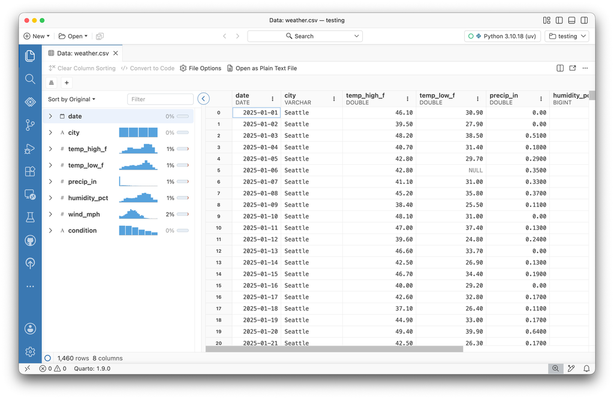

Data Explorer 開啟 weather.csv：Summary panel 逐欄列出型別、分布與缺值%，Data Grid 顯示列資料，上方動作列有 Convert to Code 與 Open as Plain Text File

用 Summary panel 及早抓問題

它是最快發現問題的地方：某欄大半是缺值、數字被存成文字、出現意外的類別。分析之前就能抓到，避免後面踩雷。

把探索變成程式碼：Convert to Code

篩選、排序到想要的檢視後，按動作列的 **Convert to Code**，Positron 會產生能重現該檢視的 Python、R 或 SQL 程式碼，讓隨手探索變成可重現的分析步驟。

#### 小結

- 預覽是「低成本」認識資料集的方式，之後再決定怎麼載入。
- 哪個部分做什麼：Data Grid 看列、Summary panel 看每欄的剖面、Filter bar 聚焦子集——全都不會碰原始檔案。

### 關鍵詞

- **Data Explorer**：Positron 內建的表格資料檢視器，可開檔案或記憶體中的 data frame。
- **Data Grid**：Data Explorer 的列欄格線，可捲動、依欄排序。
- **Summary panel**：逐欄顯示型別、缺值、分布的摘要面板。
- **Filter bar**：縮小檢視範圍的篩選控制，不改原檔。
- **Convert to Code**：把目前的排序／篩選檢視轉成 Python、R 或 SQL 程式碼。
- **Open as Plain Text File**：切換成原始純文字檢視。
- **DuckDB**：Data Explorer 讀取檔案時使用的引擎。

### 可執行要點

- 在 Positron 的 Explorer 選一個 CSV 或 Parquet，確認它在 Data Explorer 開啟
- 先看 Summary panel：找出缺值多、型別不對、類別怪異的欄位
- 試著排序與篩選，再按 Convert to Code 取得可重現的程式碼
- 需要看原始文字時，用 Open as Plain Text File 切換

📝 隨堂測驗（點選項作答）

你想快速看一個 Parquet 檔的內容，但不想把它載入 Python 或 R session。最好的第一步是？

Data Explorer 直接讀檔（背後用 DuckDB），不會在 session 裡產生變數。

哪個部分負責顯示每個欄位的型別、缺值比例與分布？

Data Grid 看列、Filter bar 縮小範圍；欄位剖面是 Summary panel。

排序與篩選出想要的檢視後，如何把它變成可重現的程式碼？

Convert to Code 會產生 Python、R 或 SQL 程式碼重現該檢視。

### 把資料載入 Python 與 R（Loading Data into Python and R）

Positron 入門②處理資料 · 第 2 單元

一句話總結

用一行標準讀檔指令把檔案讀成 Python／R 物件後，**Variables pane 顯示 session 中的物件與摘要，點資料圖示（或 `%view`／`View()`）即可在 Data Explorer 看完整表格**。

你會學到

- 如何用簡短標準的指令把檔案讀成 Python 或 R 物件
- Variables pane 如何列出並摘要 session 中的物件
- 如何把已載入的 data frame 在 Data Explorer 中打開檢視

### 內容筆記

#### 從檔案到變數

預覽適合快速看一眼；當你要真正處理資料（清理、轉換、建模），就把它載入 session 的變數。

Python（用 polars；也可用 pandas）：

```
import polars as pl

weather = pl.read_csv("weather.csv")
```

把 `read_csv` 換成 `read_parquet` 即可讀 Parquet。完成後 `weather` 就是 session 中的物件。

R（用 readr）：

```
library(readr)

weather <- read_csv("weather.csv")
```

讀 Parquet 用 `arrow::read_parquet()`，或用 base R 的 `read.csv()`。同樣，`weather` 成為 session 中的物件。

本課重點不在讀檔函式

重點是：資料一旦存在變數裡，Positron 提供專屬工具讓你檢視它——這是本單元其餘部分的主題。

#### 在 Variables pane 看見它

read 指令一跑完，新物件就出現在畫面右側的 **Variables** pane（這是你目前 session 中所有物件的即時檢視）。它提供三件事：

| 功能 | 說明 |
| --- | --- |
| 名稱與摘要 | 每個項目是「名稱＋簡短摘要」：data frame 顯示維度，一般值顯示值本身 |
| 欄位細節 | 展開 data frame 可看每一欄的值預覽與型別 |
| 即時 session | 載入就出現；重啟 session 後 pane 會清空 |

以 `weather` 為例，摘要是「1460 rows × 8 columns」，展開後每欄一列：date（Date）、city（字串，1460 筆）、temp_high_f、temp_low_f、precip_in、humidity_pct、wind_mph（皆為數值 double，1460 筆，缺值以 NA 顯示）、condition（字串）。

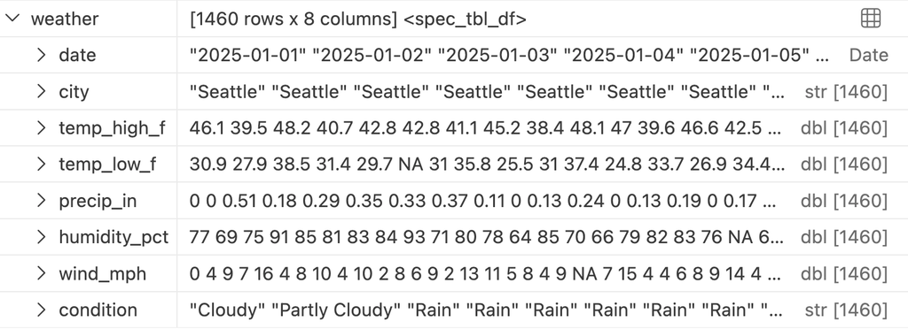

Variables pane 中展開的 weather：摘要 1460 rows x 8 columns，逐欄列出值預覽與型別（date、city、temp_high_f 等 8 欄）

確認資料有沒有真的載入

Variables pane 是最快的確認方式。若預期的物件不在，檢查 read 指令是否無錯誤執行，以及結果是否有指派給變數（`<-` 或 `=`）。

重啟 session 會清掉物件

載入 `weather` 後若重啟 session，Variables pane 中它就不見了——因為重啟清除了 session，需要重新執行載入指令。檔案本身（`weather.csv`）不會被刪。

#### 在 Data Explorer 打開已載入的物件

Variables pane 給摘要；想要完整的類試算表檢視，就把 data frame 在 Data Explorer 打開（與上一單元預覽檔案用的是同一個工具）。

最簡單：在 Variables pane 找到該 data frame，點它旁邊的**資料圖示**（一個格線／表格形狀的小圖示），就會在 Data Explorer 開啟。也可以用程式碼：

```
%view weather
```

```
View(weather)
```

開啟後分頁標題是 `Data: weather`，內容有 Summary panel（每欄的直方圖與缺值百分比）與可捲動的 Data Grid，上方動作列有 Clear Column Sorting 與 Convert to Code。

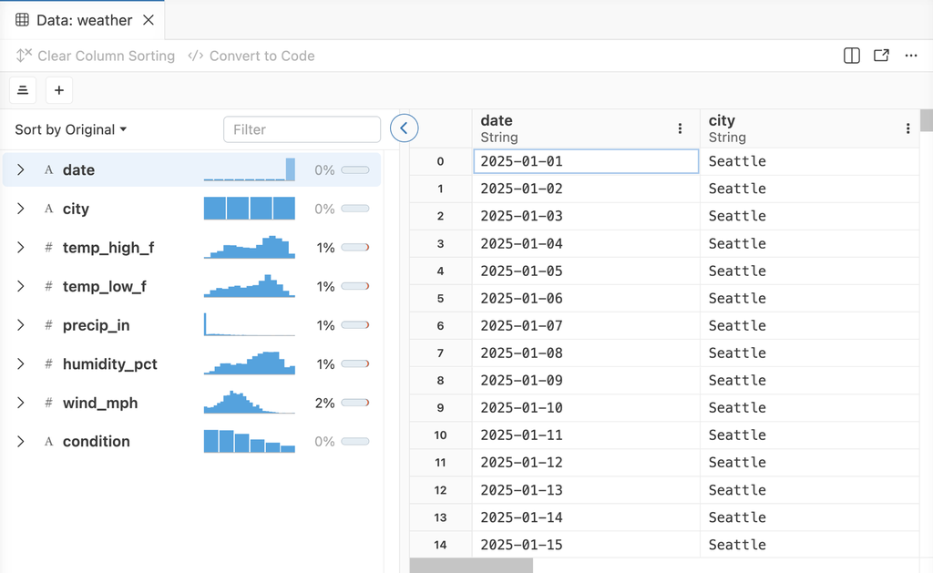

已載入的 weather 在 Data Explorer 的畫面：分頁標題 Data: weather，Summary panel 顯示各欄分布與缺值百分比，旁邊是可捲動的 Data Grid

同一個 Data Explorer，兩種入口

檔案從 Explorer 開；已載入的物件從 Variables pane 開（或 `%view`／`View()`）。兩種方式得到相同的 Data Grid、Summary panel、Filter bar。

### 關鍵詞

- **Variables pane**：顯示目前 session 所有物件與摘要的即時面板。
- **`%view`**：Python 中在 Data Explorer 開啟物件的魔術指令。
- **`View()`**：R 中對應的函式（RStudio 使用者熟悉，Positron 中會開 Data Explorer）。
- **資料圖示**：Variables pane 中 data frame 旁的小表格圖示，點下即開 Data Explorer。

### 可執行要點

- 用 `read_csv`（R 或 polars）把一個檔案讀成 `weather` 類變數
- 在 Variables pane 展開，核對列數、欄數與各欄型別
- 分別用資料圖示和 `View()`／`%view` 開 Data Explorer
- 記得重啟 session 後要重新載入資料

📝 隨堂測驗（點選項作答）

你載入 weather 後重啟 session，Variables pane 中 weather 不見了。原因是？

Variables pane 反映即時 session；重啟後物件消失，檔案仍在。

已載入 weather 後，哪個做法「不能」在 Data Explorer 打開它的 session 物件？

Plots pane 是看圖的地方，與開啟 data frame 無關。

Python 要讀 Parquet 檔（polars）應把 read_csv 換成什麼？

原文：swap read_csv for read_parquet。R 端則用 arrow::read_parquet()。

### 用 Data Connections 連接資料庫（Connecting to Databases with Data Connections）

Positron 入門②處理資料 · 第 3 單元

一句話總結

開啟預覽功能 **Data Connections** 後，可把資料庫存成連線、不寫 SQL 就逐層瀏覽表格、在 Data Explorer 預覽，並用 **Connect With** 自動產生 Python／R 連線程式碼。

你會學到

- Data Connections 是什麼、如何啟用
- 如何新增本機 DuckDB 資料庫的連線
- 如何瀏覽表格並在 Data Explorer 預覽
- 如何產生可直接執行的 Python／R 連線程式碼

前置條件：Data Connections 是預覽功能，先啟用

1. 開啟 Settings（macOS 按 Cmd+,；Windows／Linux 按 Ctrl+,）。
2. 搜尋 `dataConnections.enabled` 並勾選。
3. 重新載入 Positron 讓設定生效。

### 內容筆記

#### Data Connections 做什麼

資料不只存在檔案，很多在資料庫與資料倉儲。**Data Connections** 是 Positron 主側邊欄的一個檢視，可：儲存資料庫／資料倉儲連線、瀏覽內容（catalog、schema、table、view、column）、在 Data Explorer 預覽表格、產生 Python／R 連線程式碼。

開箱即支援：DuckDB、SQLite、PostgreSQL、Snowflake、Databricks、Redshift，以及任何已安裝本機 ODBC 驅動程式的資料庫。儲存連線時，密碼、token、連線字串存放在**作業系統的 secret storage**，而非明文。

預覽功能會持續演進

介面以官方 Data Connections 文件為準（positron.posit.co/data-connections.html）。

#### 連到本機 DuckDB

DuckDB 很適合入門：在本機執行、不需架伺服器，整個資料庫就是你電腦上的一個檔案，所以沒有憑證要管理。

1. 開啟 Data Connections 檢視（activity bar 上的資料庫圖示），按頂端的 **+**（Add Connection）。
2. 在 **Add Data Connection** 對話框，按 DuckDB 旁邊的 **Connect**。
3. 為連線命名（範例：`Weather Data`），按 **Browse** 選資料庫檔案（範例：`weather.duckdb`）。
4. 按 **Save**。

連線出現在樹狀清單中，可供瀏覽。原文有一段動畫示範整個流程：新增連線、選 DuckDB、命名、瀏覽選檔、儲存，接著展開連線經 Tables 到 `weather` 表與其欄位，再於 Data Explorer 開啟該表——展開與預覽的步驟見下一節。

連線會被儲存，下次開 Positron 仍在，不必重設。

Read Only

DuckDB 與 SQLite 連線有 **Read Only** 勾選框。只想看資料時請保持勾選：你做什麼都不會改動資料庫，且連線開著時其他 session 仍可開同一個檔案。

#### 瀏覽與預覽

連線儲存後變成可瀏覽的樹，不用寫任何 SQL：

1. 展開連線以開啟它。**綠點**表示連線是活的。
2. 展開 **Tables**（或 **Views**）看資料庫內容。
3. 展開某張表可看其 **Columns**（含資料型別）與 **Indexes**。
4. 對表雙擊（或右鍵選 **Open in Data Explorer**），即在 Data Explorer 預覽。

若資料庫有多個 schema，樹中會在表之上多一層 schema；本例的簡單 DuckDB 只有一個 schema，Positron 會直接顯示其 tables 與 views。

同一個 Data Explorer

資料庫表格也能排序、篩選、看欄位剖面，與檔案一樣。

用完後收合連線即斷線；若還有該連線開啟的 Data Explorer 分頁，連線會維持到最後一個分頁關閉。

#### 在程式中使用連線：Connect With

瀏覽用來熟悉環境；要在腳本或 notebook 查詢時，Data Connections 能幫你寫連線程式碼：

1. 對連線按右鍵，選 **Connect With**，再選 **Python** 或 **R**。
2. 在對話框檢視產生的程式碼。
3. 按 **Copy** 複製到剪貼簿、**Create Script** 在新檔開啟、或 **Connect** 在目前 console 執行。

DuckDB 產生的程式碼很短，大致如下：

```
import duckdb

con = duckdb.connect("weather.duckdb")
```

```
library(DBI)

con <- dbConnect(duckdb::duckdb(), "weather.duckdb")
```

憑證與 Include Secrets

需要憑證的資料庫，產生的程式碼會引用你儲存的 secret，而不是把密碼寫進去。另有 **Include Secrets** 勾選框可把憑證直接放進程式碼，但 Positron 會先要求確認，因為任何看到該程式碼的人都能看到你的憑證。

### 關鍵詞

- **Data Connections**：儲存／瀏覽資料庫連線的側邊欄檢視（預覽功能）。
- **`dataConnections.enabled`**：啟用此功能的設定鍵。
- **Add Connection（+）**：新增連線按鈕。
- **Read Only**：唯讀勾選（DuckDB、SQLite）。
- **Connect With**：右鍵選單，產生 Python／R 連線程式碼。
- **Include Secrets**：把憑證直接寫入產生的程式碼（需確認，不建議）。
- **DuckDB**：單檔、本機執行的分析型資料庫。

### 可執行要點

- 在 Settings 啟用 `dataConnections.enabled` 並重新載入 Positron
- 新增一個 DuckDB 連線（命名、Browse 選檔、Save），建議維持 Read Only
- 展開 Tables，雙擊一張表在 Data Explorer 預覽
- 右鍵 Connect With 取得 Python／R 程式碼，用 Create Script 開成腳本
- 除非必要，不要勾 Include Secrets

📝 隨堂測驗（點選項作答）

已儲存 DuckDB 連線，想在 Python 腳本查詢。取得連線程式碼最快的方式是？

Connect With 會產生可複製、建腳本或直接執行的連線程式碼。

儲存連線時，密碼與 token 放在哪裡？

Positron 把憑證存在作業系統的 secret storage，而非明文。

樹狀清單中連線旁的綠點代表什麼？

綠點表示連線 live。

### 分析資料：圖表、表格與 Viewer（Analyzing Data: Plots, Tables, and the Viewer）

Positron 入門②處理資料 · 第 4 單元

一句話總結

分析輸出去哪由類型決定：**圖（靜態或互動）進 Plots pane、App 與文件型輸出（含 HTML 表格）進 Viewer、純文字列印留在 console**。

你會學到

- 圖表出現在 Positron 哪裡，以及如何瀏覽、縮放、儲存
- Shiny app 與渲染後的報告如何顯示在 Viewer
- 靜態表格與互動表格各自出現在哪

### 內容筆記

#### 圖表進 Plots pane

資料載入後，通常先產生圖。執行畫圖程式時，Positron 會攔截並顯示在右側的 **Plots** pane。連互動圖也一樣：凡 Positron 判斷為「像圖」的輸出（如 plotly 圖、`leaflet` 地圖）都進 Plots pane，與靜態圖並列。

```
import seaborn as sns

sns.scatterplot(weather, x="temp_low_f", y="temp_high_f", hue="city")
```

```
library(ggplot2)

ggplot(weather, aes(temp_low_f, temp_high_f, color = city)) +
  geom_point()
```

下圖是 Python 版的結果：以 temp_low_f 為 x、temp_high_f 為 y 的散佈圖，依城市（Seattle、Denver、Miami、Chicago）上色，整體呈明顯正相關；上方是 Plots 工具列，右側是歷史縮圖條，列有這張 seaborn 圖和先前的一張 ggplot2 圖。

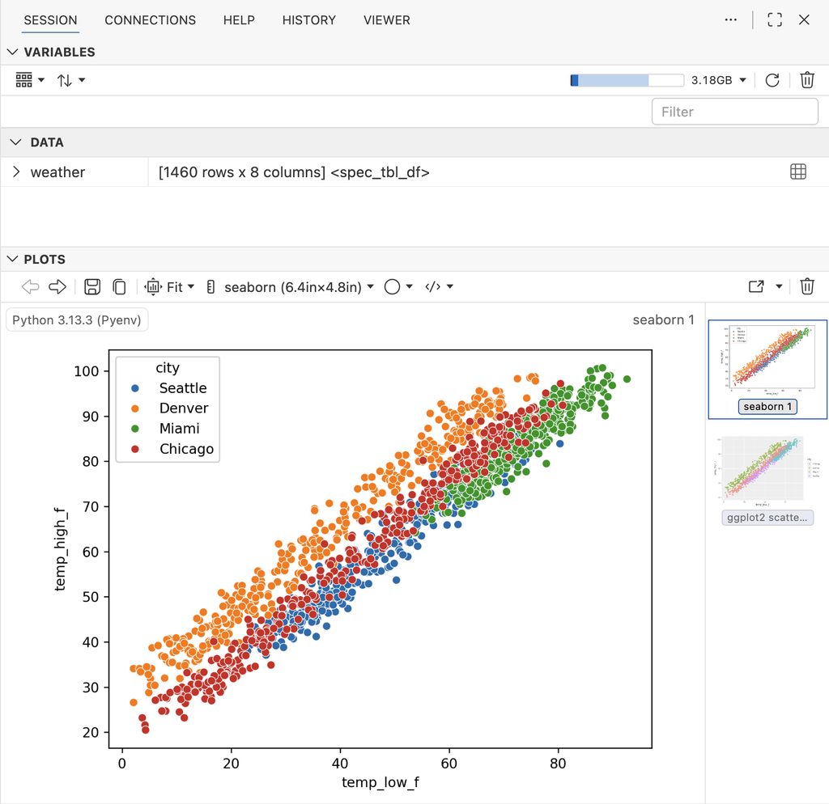

Plots pane 顯示 seaborn 散佈圖（temp_low_f 對 temp_high_f，依城市上色），上方有工具列，右側歷史縮圖含 seaborn 與 ggplot2 兩張圖

Plots pane 保存整個 session 的圖表歷史，可前後切換並匯出想要的那張：

| 工具列動作 | 功能 |
| --- | --- |
| Previous / Next | 在圖表歷史中前後翻 |
| Zoom | 放大圖，或在獨立分頁／視窗開啟 |
| Copy | 複製圖到剪貼簿以貼到別處 |
| Save | 匯出成檔案（PNG、SVG、PDF 等） |

每張圖標註產生它的語言

所以 Python 與 R 混用的 session 也容易分辨（上圖歷史中即有 seaborn 與 ggplot2 兩種）。

#### App 與報告進 Viewer

非圖的輸出，由 **Viewer** pane 顯示：App 與文件型的網頁內容——平常會用瀏覽器開的東西。經典例子是在 Positron 內執行 Shiny app；渲染後的 Quarto 與 R Markdown 報告也在這裡。

注意：決定去哪個 pane 的不是「是不是 HTML」；圖型的 HTML 輸出（如 plotly、leaflet）進 Plots pane。Viewer 專收行為像 App 或文件的輸出，可直接捲動、點擊、互動，不必離開 IDE。（原文動畫示範：在 Viewer 中調整 Shiny 的輸入控制項，圖即時更新。）

#### 表格：靜態與互動

**靜態表格**：以純文字列印到 console，適合快速看摘要或前幾列。

```
weather.head()
```

輸出為 console 的等寬文字表格：先印 `shape: (5, 8)`，再列欄名、各欄型別（str、f64、i64）與前五列資料。

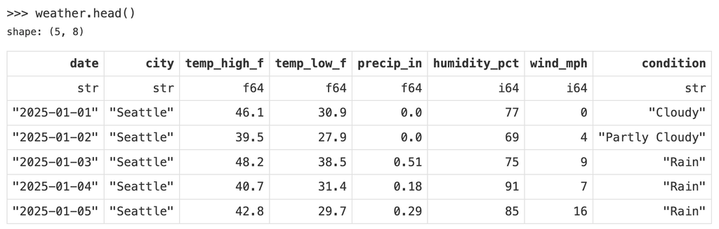

console 中 weather.head() 的輸出：shape (5, 8)，欄名、型別與前五列資料，皆為等寬純文字

**互動表格**：以 HTML 在 Viewer 渲染，而非 console 純文字。下例用 `great_tables` 格式化；R 可用 `gt` 與 `DT`，其中 `DT` 另有捲動、排序、搜尋。

```
from great_tables import GT

GT(weather.head(10))
```

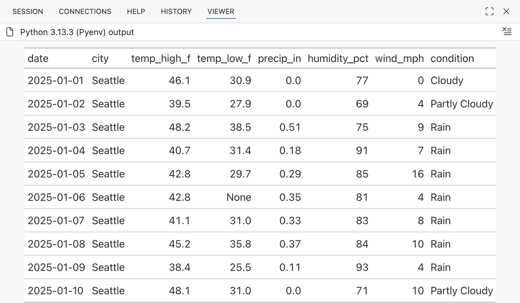

Viewer pane 顯示 great_tables 產生的 weather 前 10 列 HTML 表格，缺值顯示為 None

一條規則

圖（靜態或互動）→ Plots pane；純列印輸出 → console；App 或文件型輸出（Shiny app、渲染報告、HTML 表格）→ Viewer。

#### 分類練習（改寫）

| 輸出 | 去處 |
| --- | --- |
| seaborn 散佈圖、ggplot2 圖、`leaflet` 地圖 | Plots pane |
| Shiny app、渲染後的 Quarto 報告、`great_tables` 表格 | Viewer |
| `weather.head()` 的列印、模型摘要的列印 | console |

### 關鍵詞

- **Plots pane**：顯示圖表（含互動圖）並保存歷史的面板。
- **Viewer pane**：顯示 App 與文件型網頁輸出。
- **靜態表格**：純文字列印在 console。
- **互動表格**：HTML 表格（`great_tables`、`gt`、`DT`）在 Viewer 渲染。
- **Shiny**：R／Python 的互動式網頁 App 框架。

### 可執行要點

- 畫一張圖，練習在 Plots pane 前後翻、Zoom、Copy、Save
- 用 `gt` 或 `DT`（R）或 `great_tables`（Python）做表，確認在 Viewer 出現
- 用 `leaflet` 或 plotly 畫互動圖，確認它進的是 Plots pane
- 記住那條規則：圖進 Plots、文字進 console、App／文件進 Viewer

📝 隨堂測驗（點選項作答）

你用 leaflet 套件做了互動地圖，Positron 會顯示在哪？

被判斷為圖型的輸出（含 plotly、leaflet）都進 Plots pane。

哪一種輸出會出現在 Viewer？

HTML 表格屬於文件型輸出，在 Viewer 渲染；圖進 Plots、列印進 console。

想把 Plots pane 的某張圖存成 PNG 或 PDF，用哪個工具列動作？

Save 匯出成 PNG、SVG、PDF 等檔案。

### 課程總複習（Course Recap）

Positron 入門②處理資料 · 第 6 單元

一句話總結

在 Positron 處理資料的流程是 **預覽 → 載入 → 連線 → 轉成程式碼 → 分析輸出**，每一步都有對應的內建面板。

你會學到

- 不載入就用 Data Explorer 預覽 CSV、Parquet 等表格檔
- 載入 Python／R 並用 Variables pane 與 Data Explorer 檢查
- 用 Data Connections 連資料庫、瀏覽表格、產生連線程式碼
- 圖、App、報告、表格各自顯示在哪

### 內容筆記

#### Positron 的資料工作流程

| 步驟 | 做什麼 |
| --- | --- |
| 1. Preview（預覽） | 在 Explorer 選資料檔，以 Data Explorer 開啟；寫程式前先看 Summary panel |
| 2. Load（載入） | 把檔案讀進變數，在 Variables pane 確認，再從那裡開 Data Explorer |
| 3. Connect（連線） | 在 Data Connections 新增資料庫、瀏覽表格、雙擊預覽 |
| 4. Bring it into code（轉成程式碼） | 用 **Connect With** 產生連線程式碼；或用 **Convert to Code** 把篩選後的 Data Explorer 檢視轉成程式碼 |
| 5. Analyze（分析） | 圖進 Plots pane、App 與報告進 Viewer、純列印留在 console |

#### 哪個功能在哪裡（速查表）

| 當你想要… | 該用 |
| --- | --- |
| 不載入就看資料檔內容 | Data Explorer（在 Explorer 選檔案） |
| 確認 session 載入了什麼 | Variables pane |
| 逐列檢查已載入的 data frame | Data Explorer（資料圖示、`%view` 或 `View()`） |
| 瀏覽資料庫的表格 | Data Connections |
| 取得連到已存資料庫的程式碼 | Data Connections 的 **Connect With** |
| 看圖（靜態或互動） | Plots pane |
| 執行 Shiny app 或讀渲染後的報告 | Viewer |

#### 各單元重點回顧

- **第 1 單元**：Data Explorer 預覽 `.csv`、`.tsv`、`.parquet`、`.xlsx`、壓縮檔；Data Grid／Summary panel／Filter bar；Convert to Code。
- **第 2 單元**：`read_csv`（R 的 readr、Python 的 polars）等讀檔；Variables pane 反映即時 session、重啟即清空；`%view`／`View()`。
- **第 3 單元**：啟用 `dataConnections.enabled`；Add Connection 存連線（憑證放 OS secret storage）；展開 Tables、雙擊預覽；Connect With 產生 `duckdb.connect()` 或 `dbConnect(duckdb::duckdb(), ...)` 程式碼。
- **第 4 單元**：Plots pane 的歷史與 Zoom／Copy／Save；Viewer 收 App 與文件型輸出；靜態表格在 console、互動表格在 Viewer。

#### 下一步

- 用你自己的資料集走完整個流程：預覽、載入，並做一張圖與一張表。
- 透過 Data Connections 連上工作中使用的資料庫，用 **Connect With** 起一支腳本。
- 這些工具仍在演進，常查官方文件：Data Explorer（positron.posit.co/data-explorer.html）與 Data Connections（positron.posit.co/data-connections.html）。

（補充）原課程第 5 單元是在 Positron 內動手實作的 capstone，網頁無文字內容，本筆記未涵蓋；建議自己用上面「下一步」第一項當作練習。

### 關鍵詞

- **Data Explorer**：檔案與 data frame 的類試算表檢視器。
- **Variables pane**：session 物件即時清單。
- **Data Connections**：資料庫連線管理（預覽功能）。
- **Connect With／Convert to Code**：兩個「產生程式碼」的入口，前者產生連線、後者重現檢視。
- **Plots pane／Viewer／console**：三個輸出去處。

### 可執行要點

- 對一個新資料檔，養成「先預覽、再決定怎麼載入」的習慣
- 載入後用 Variables pane 核對維度與型別
- 把資料庫連線存進 Data Connections，用 Connect With 產生腳本
- 分析時依規則找輸出：圖→Plots、App／報告／HTML 表格→Viewer、列印→console

📝 隨堂測驗（點選項作答）

你想知道目前 session 載入了哪些物件，最快看哪裡？

Variables pane 是 session 的即時清單。

要把篩選後的 Data Explorer 檢視變成可重現的程式碼，用哪個功能？

Connect With 產生連線程式碼；Convert to Code 重現檢視。

渲染後的 Quarto 報告會顯示在哪？

App 與文件型輸出進 Viewer。

📕

## Positron 入門③執行與管理程式（24 分）

· 5 篇

**🗺️ 本課地圖（點單元標題可跳到那一篇）**

| 執行腳本（Running Scripts） | 腳本是「存放程式碼的地方」、Console 的 session 才是「執行程式碼的地方」；在腳本裡按 **Cmd/Ctrl+Enter** 就是把當前一個完整陳述式送進 session 跑，選取後可跑一段，播放鈕可跑整個檔案。 |
| --- | --- |
| 使用 Positron Notebook（Working with Positron Notebooks） | Notebook 是由「儲存格（cell）」組成、把程式碼、文字與輸出放在同一份文件的格式；**探索與說故事用 notebook，要重跑的管線用腳本**，而 Positron 的原生 notebook 編輯器讓 Variables 窗格、Data Explorer 照常可用。 |
| 建立專案與管理環境（Creating Projects and Managing Environments） | **一個專案一個資料夾**：用 **New Folder from Template** 一次建好環境（Python 的 `venv`、R 的 `renv`）、`.gitignore` 與選用的 Git，讓每個專案的套件彼此隔離、可重現。 |
| 用 Git 做版本控制（Version Control with Git） | 在 Positron 的 **Source Control** 檢視裡就能完成 Git 日常循環：**檢視變更 → stage → commit**，再用 **Publish Branch**／**Sync** 把專案推到 GitHub 等遠端備份與分享。 |
| 課程總複習（Course Recap） | 整門課濃縮成一個循環：**用範本開專案 → 寫並執行程式 → 用 notebook 探索 → commit → push**，搭配一張快捷鍵與控制項速查表即可上手。 |

### 執行腳本（Running Scripts）

Positron 入門③執行與管理程式 · 第 1 單元

一句話總結

腳本是「存放程式碼的地方」、Console 的 session 才是「執行程式碼的地方」；在腳本裡按 **Cmd/Ctrl+Enter** 就是把當前一個完整陳述式送進 session 跑，選取後可跑一段，播放鈕可跑整個檔案。

你會學到

- 從腳本執行的程式碼如何進到 Console 顯示的同一個 interpreter session
- 三種執行方式：一個陳述式（statement）、一段選取範圍、整個檔案
- 對應的快捷鍵（Mac／Windows／Linux），以及與 RStudio 的關係

### 內容筆記

#### 腳本與 session 的關係

直接在 Console 打幾行程式碼適合快速試算，但真正的分析會寫在**腳本（script）**裡：像 `analysis.py`、`analysis.R` 這種可儲存、可重跑、可分享的純文字檔。

核心心智模型：

腳本 vs. session

腳本是程式碼「住的地方」，session 是程式碼「跑的地方」。腳本檔本身並沒有綁定任何 session，它只是你從中送出程式碼的來源。

| 角色 | 功能 |
| --- | --- |
| 腳本（編輯器） | 你儲存的永久紀錄。可隨意編輯、邊寫邊跑一小段、隨時整份重跑 |
| Console | 即時運作中的 session。從腳本送出的每一行都會出現在這裡，與你直接在 Console 打的指令並列 |

從腳本執行程式碼，就是把它送到目前「作用中的（active）」interpreter session——也就是 Console 顯示的那一個，所以程式碼建立的變數就存在那個 session 裡。切到 Console 直接輸入變數名稱即可看到它。

#### 三種執行方式

不必每次都從頭跑到尾。Positron 提供三種粒度。以下用原課的示範腳本為例（Python）：

```
x = 5
y = 10
print(x + y)
```

**1. 執行一個陳述式（Run one statement）**

游標放在任一行上，按 `Cmd+Enter`（Mac）或 `Ctrl+Enter`（Windows/Linux）。Positron 會把「目前這個陳述式」送到 Console 執行，然後把游標移到下一個陳述式；連續按同一個快捷鍵，就能一步一步走完整份腳本。

是「陳述式」不是「一行」

Positron 執行的是完整的 *statement*。如果游標落在多行的函式呼叫或 pipeline（管線）中間，`Cmd/Ctrl+Enter` 會把整段一起跑。

**2. 執行選取範圍（Run a selection）**

用滑鼠反白一段程式碼，再按同一個快捷鍵 `Cmd/Ctrl+Enter`，只有反白的部分會被執行（一次全部送進 Console）。適合重跑幾行相關的程式碼，而不想逐句按。

**3. 執行整個檔案（Run the whole file）**

點編輯器動作列（editor action bar，位於編輯器左上方）的**播放鈕（play button，三角形圖示）**，或按 `Cmd+Shift+Enter`（Mac）／`Ctrl+Shift+Enter`（Windows/Linux），整份腳本從頭跑到尾，輸出都出現在 Console。

#### 速查表

| 動作 | 快捷鍵 | 適用時機 |
| --- | --- | --- |
| 執行一個陳述式 | `Cmd/Ctrl+Enter` | 邊寫邊逐步檢查 |
| 執行選取範圍 | 先反白，再 `Cmd/Ctrl+Enter` | 重跑特定一段 |
| 執行整個檔案 | 播放鈕或 `Cmd/Ctrl+Shift+Enter` | 腳本寫完，從頭到尾執行 |

從 RStudio 轉來的人

這些快捷鍵與 RStudio 相同，肌肉記憶可直接沿用。若再啟用 **RStudio keymap**（RStudio 按鍵對應；官方說明頁 positron.posit.co/migrate-rstudio-keybindings.html），其餘的快捷鍵也會一併沿用。

想自己試？

還沒裝 Positron 的話，可從 positron.posit.co/download.html 免費下載。

### 可執行要點

- 把分析寫在腳本檔裡，不要只在 Console 打指令
- 邊寫邊測時用 `Cmd/Ctrl+Enter` 一個陳述式一個陳述式跑
- 要重跑某幾行時，先反白再按 `Cmd/Ctrl+Enter`
- 腳本完成後用播放鈕或 `Cmd/Ctrl+Shift+Enter` 從頭到尾跑一次確認
- 跑完切到 Console 輸入變數名稱，確認變數確實在 session 裡

📝 隨堂測驗（點選項作答）

游標在腳本某一行上，按 Cmd/Ctrl+Enter 會發生什麼事？

Cmd/Ctrl+Enter 執行當前陳述式並前進到下一個；整份檔案要用播放鈕或 Cmd/Ctrl+Shift+Enter。

你從腳本跑了幾行建立 data frame，接著在 Console 直接輸入它的名稱也能印出來。為什麼？

腳本只是來源，程式碼實際在作用中的 session 執行，變數就存在該 session。

游標在多行的函式呼叫中間，按 Cmd/Ctrl+Enter 會執行什麼？

Positron 以完整的 statement 為單位執行。

### 使用 Positron Notebook（Working with Positron Notebooks）

Positron 入門③執行與管理程式 · 第 2 單元

一句話總結

Notebook 是由「儲存格（cell）」組成、把程式碼、文字與輸出放在同一份文件的格式；**探索與說故事用 notebook，要重跑的管線用腳本**，而 Positron 的原生 notebook 編輯器讓 Variables 窗格、Data Explorer 照常可用。

你會學到

- 何時 notebook 比腳本更適合
- 如何建立 Positron notebook、必要時切換 kernel
- 如何執行程式碼儲存格、加入 markdown、閱讀內嵌輸出

### 內容筆記

#### 腳本還是 Notebook？

上一單元談腳本；notebook 是另一種組織工作的方式：不是一個程式碼檔，而是一串**儲存格（cells）**，把程式碼、文字、輸出混在同一份文件。兩者沒有誰比較好，只是適合的工作不同。

| 適合用腳本 | 適合用 notebook |
| --- | --- |
| 要從頭到尾重跑的東西（資料管線、報表排程工作） | 探索資料，想讓結果緊貼著產生它的程式碼 |
| 程式碼比周邊敘述重要 | 要說故事：分析敘述、圖表、結論放在一起 |
| 想要最簡單、最好做版本控制與分享的檔案 | 要給同事閱讀、對方不用執行就看得懂 |

原課的分類練習：每晚重跑的資料管線、排程報表工作、要保持簡單以便版本控制的小清理步驟 → 腳本；用圖表探索新資料集、不必執行就能讀的分析報告、混合敘述文字／程式碼／圖的文件 → notebook。

Notebook 檔案格式

Positron 的 notebook 是標準 Jupyter `.ipynb` 檔，在 JupyterLab、VS Code 或任何支援 notebook 的地方都能開。

那 Quarto 呢？

Quarto（`.qmd`）文件同樣能混合程式碼、敘述與內嵌輸出，本單元幾乎所有內容也適用。選哪種格式多半是偏好。若遇到 `.ipynb` 的麻煩——版本控制的 diff 很雜、「一切都是 cell」的限制——通常下一步就是改用 `.qmd`：對版本控制更友善，也支援更複雜的文件。

#### Positron Notebook 編輯器

Positron 內建專為資料科學設計的**原生 notebook 編輯器**，是 `.ipynb` 的預設編輯器；你在 Positron 已經在用的東西（Variables 窗格、Data Explorer、內嵌說明）在裡面都能用。

建立 notebook 的步驟：

1. 點左上角的 **New** 下拉選單
2. 選 **New Notebook**
3. Positron 自動啟動一個 kernel，馬上可寫程式
4. 想換語言或版本，用 notebook 工具列的 **kernel picker（kernel 選擇器）** 切換

Python 與 R 的 kernel 都可使用。

#### 儲存格：程式碼、Markdown 與輸出

工作循環很簡單：在儲存格寫程式碼 → 執行 → 輸出直接顯示在該儲存格下方。表格、圖、列印結果都會內嵌呈現（原課示範：在 Python 儲存格寫繪圖程式碼、按 `Cmd+Enter` 執行，圖就出現在儲存格正下方）。

| 動作 | 快捷鍵 |
| --- | --- |
| 執行儲存格並移到下一格 | `Shift+Enter` |
| 執行儲存格並留在原地 | `Cmd/Ctrl+Enter` |
| 新增儲存格 | 儲存格之間的 `+ Code`／`+ Markdown` 按鈕 |

要加敘述，就插入 **markdown 儲存格**：可寫標題、項目符號、連結；執行該格後會轉成排版好的文字。這就是把一堆程式碼變成可讀分析的關鍵。操作步驟：點新增 markdown 儲存格的按鈕 → 輸入標題與一句話 → 執行該格，內容即渲染成格式化文字。

工作階段工具仍在

在 notebook 裡，儲存格建立的變數會顯示在 Variables 窗格，仍可把任何 data frame 在 Data Explorer 打開。

### 可執行要點

- 要排程或從頭到尾重跑的工作寫成腳本；探索與寫報告用 notebook
- 用 New > New Notebook 建 notebook，確認 kernel 是想用的語言／版本
- 熟記 `Shift+Enter`（跑完往下）與 `Cmd/Ctrl+Enter`（跑完留原地）
- 用 markdown 儲存格寫標題與結論，讓同事不用執行也能讀
- 若覺得 `.ipynb` 的版本控制 diff 太雜，考慮改用 `.qmd`

📝 隨堂測驗（點選項作答）

以下哪項工作最適合寫成腳本而非 notebook？

腳本適合要重跑、排程的程式碼；notebook 適合探索與說故事。

你選了 New Notebook 想跑 Python，在跑第一個儲存格前需要做什麼？

Positron 會自動啟動 kernel；只有想換語言或版本時才用 kernel picker。

Shift+Enter 在 notebook 儲存格中做什麼？

Shift+Enter 跑完往下；Cmd/Ctrl+Enter 跑完留在原地。

### 建立專案與管理環境（Creating Projects and Managing Environments）

Positron 入門③執行與管理程式 · 第 3 單元

一句話總結

**一個專案一個資料夾**：用 **New Folder from Template** 一次建好環境（Python 的 `venv`、R 的 `renv`）、`.gitignore` 與選用的 Git，讓每個專案的套件彼此隔離、可重現。

你會學到

- 為何一專案一資料夾，以及 Positron 如何把「開啟的資料夾」當作工作區（workspace）
- 如何用 New Folder from Template 建立新專案
- renv（R）與 venv（Python）的作用，以及它們會在專案裡加什麼檔案

### 內容筆記

#### 一個專案一個資料夾

實際工作中，腳本與 notebook 應從一開始就有組織良好的家：一個專案一個資料夾，程式碼、資料、輸出放一起。

在 Positron，**工作區（workspace）**就是你開啟的資料夾；裡面有什麼（程式碼、資料、環境、Git 歷史），Positron 就處理什麼。開啟資料夾後一切都以它為範圍：Explorer 顯示它的檔案、Console 在該資料夾啟動、相對路徑在其中解析。

Folder Selector

視窗右上角的 **Folder Selector** 顯示目前開啟的資料夾，並可在最近的資料夾間切換。它是一個按鈕：左側資料夾圖示、中間資料夾名稱，右側下拉箭頭。

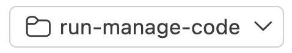

Folder Selector 按鈕：資料夾圖示、目前資料夾名稱 run-manage-code、右側下拉箭頭

#### New Folder from Template

Positron 能替你建好結構良好的專案資料夾。開啟左上角 **New** 下拉選單（或右上角 Folder Selector），選 **New Folder from Template**。New 選單內容依序為：New File、New Folder from Template、New Folder from Git、New Window。

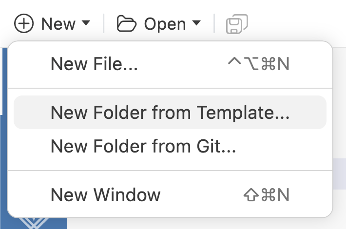

New 下拉選單展開：New File、New Folder from Template（被選中）、New Folder from Git、New Window

對話框引導三個選擇：

1. **選範本**：Python Project、R Project、Jupyter Notebook 或 Empty Project
2. **命名資料夾**並選擇存放位置
3. **設定選項**：用哪個 interpreter、是否建立環境、是否初始化 Git repository

完整流程（以建立附虛擬環境的 Python 專案為例）：開 New 選單 → New Folder from Template → 選 Python Project → 取名 → 接受預設值 → Positron 把新專案開成工作區。R Project 範本流程相同，只差環境那一項。

完成後新資料夾已有一些骨架：

| 你得到 | 用途 |
| --- | --- |
| 專屬環境（Python 為 `.venv/`；R 若勾選 renv 則為 `renv/`） | 讓這個專案的套件隔離 |
| `.gitignore` 檔 | 預填該語言常見的忽略規則 |
| Git repository（選用） | 從第一天就有版本控制（下一單元詳述） |

為什麼用範本

範本比建空資料夾好，因為可重現性的零件（環境、`.gitignore`、Git）在你寫第一行程式前、最容易的時候就設好了。

#### 可重現的環境

「專屬環境」值得理解：它解決每位資料科學家遲早會碰到的問題——兩個專案需要同一套件的不同版本。

專案的**環境（environment）**是屬於該專案的一組隔離套件。每個專案取得它需要的確切版本，為某專案安裝東西不會弄壞別的專案。

##### Python：venv

Python 專案範本預設建立**虛擬環境**（`.venv` 資料夾）。Positron 用標準 `venv` 工具建構，若已安裝 [uv](https://docs.astral.sh/uv/) 則用 uv。無論哪種，Positron 都會自動把此環境選為專案的 interpreter，所以你安裝的套件會裝進專案、而非全系統。視窗上方的 interpreter 選擇器會顯示目前環境名稱，讓你隨時知道哪個環境在作用。

```
my-project/
├── .venv/          # 專案自己的套件與 interpreter
├── .gitignore
└── my-script.py
```

一個專案一個 .venv

讓 Positron 管理選擇。同事 clone 你的專案後，會建立自己的 `.venv` 並安裝同樣的套件。

##### R：renv

R 專案範本在設定時提供 **renv** 核取方塊。renv 給專案一個私有套件庫，加上一份**鎖定檔（lockfile，`renv.lock`）**，記錄你用的確切套件版本，讓別人能重建你的環境。

```
my-project/
├── renv/           # 專案私有套件庫
├── renv.lock       # 確切套件版本，用於可重現
├── .Rprofile       # 專案開啟時啟用 renv
└── my-script.R
```

renv 是選用的

範本預設不勾選 renv，多數專案不用也沒問題。當可重現性真的重要才用：別人必須完全照你的方式執行的專案，或幾個月後需要精確重建的專案。完整流程見 renv 文件（rstudio.github.io/renv/）。

#### 重點對照

| 問題 | 答案 |
| --- | --- |
| 範本可為你設定什麼？ | Git repository、`.gitignore`、專屬套件環境（如 `.venv`）；**不包含**自動雲端備份 |
| 兩專案需同一套件不同版本？ | 各自一個環境（Python venv、R renv）；不要共用資料夾、不要來回重裝、不要裝進同一共用套件庫 |

### 關鍵詞

- **Workspace（工作區）**：你在 Positron 開啟的資料夾
- **環境（environment）**：專案專屬、隔離的一組套件
- **venv／`.venv`**：Python 虛擬環境；有 uv 時改用 uv 建
- **renv／`renv.lock`**：R 的私有套件庫與版本鎖定檔
- **Folder Selector**：右上角顯示並切換開啟資料夾的按鈕

### 可執行要點

- 每個新專案用 New > New Folder from Template 建立，而不是空資料夾
- Python 專案保留預設的 `.venv`，並確認 interpreter 選擇器顯示的是專案環境
- R 專案若需要嚴格可重現（要給別人跑或日後重建），勾選 renv
- 新建專案時順手勾選初始化 Git repository

📝 隨堂測驗（點選項作答）

你在 Positron 開啟一個資料夾，會發生什麼？

工作區就是你開啟的資料夾，一切以它為範圍。

兩個專案需要同一套件的不同版本，建議作法是？

獨立環境讓各專案取得所需版本且互不影響。

關於 renv 的敘述何者正確？

renv 為選用，提供私有套件庫與 renv.lock。

### 用 Git 做版本控制（Version Control with Git）

Positron 入門③執行與管理程式 · 第 4 單元

一句話總結

在 Positron 的 **Source Control** 檢視裡就能完成 Git 日常循環：**檢視變更 → stage → commit**，再用 **Publish Branch**／**Sync** 把專案推到 GitHub 等遠端備份與分享。

你會學到

- repository、stage、commit、push 的意思
- 如何在 Positron 為專案初始化 Git repository
- 如何 stage 與 commit 變更，並 push 到 GitHub 等遠端

前置條件

Positron 的版本控制功能依賴機器上已安裝 Git。在終端機執行 `git --version` 檢查；若出現錯誤，請先依你的作業系統安裝 Git。

### 內容筆記

#### 為什麼要版本控制

你大概手動發明過版本控制：`analysis_final.R`、`analysis_final_v2.R`、`analysis_final_REALLY.R`。**Git** 用真正的歷史取代這團混亂：它是版本控制系統，記錄專案隨時間的快照；每個快照是可檢視、比較、回復的存檔點，也讓協作變得可管理。

四個詞撐起整個流程：

| 名詞 | 意思 |
| --- | --- |
| Repository（儲存庫） | 你的專案資料夾加上完整歷史，歷史存在隱藏的 `.git` 目錄 |
| Stage（暫存） | 挑選哪些變更的檔案要放進下一個快照 |
| Commit（提交） | 把已 stage 的變更存成快照，附一句簡短訊息 |
| Push（推送） | 把 commit 上傳到遠端副本，例如 GitHub 或 GitLab 上的 repo |

#### 建立 repository

若用範本建專案時勾選了 **Initialize Git repository**，就已完成。對既有資料夾，Positron 一鍵搞定：

1. 在活動列（activity bar）開啟 **Source Control** 檢視（分支線條圖示，見下圖）
2. 按 **Initialize Repository**

[figure not shown]

Positron 活動列中的 Source Control 圖示：藍底、由分支線連接的三個圓圈

操作後，Positron 建立隱藏的 `.git` 目錄，Source Control 檢視切換為顯示專案的未追蹤（untracked）檔案，並開始追蹤你在專案中的每個變更。

#### Stage、Commit、Push

日常循環：編輯檔案後，Source Control 檢視會列出所有有變更的檔案。下圖標註了該檢視各區域：

[figure not shown]

標註版 Positron 視窗：左側 Source Control 檢視，標出 Commit Message 輸入框、Commit 按鈕、More Git Commands（Push、Pull 等）選單、Modified Files 清單、檔案旁用來 Stage 的 + 按鈕，以及下方的 Commit History

各區域功能：

| 區域 | 功能 |
| --- | --- |
| Modified Files | 變更過的檔案清單 |
| Stage（+ 按鈕） | 把該檔案加入下一個快照 |
| Commit Message | 輸入提交訊息的框（可用 `Cmd+Enter` 提交，Mac） |
| Commit 按鈕 | 提交已 stage 的變更 |
| More Git Commands（⋯ 選單） | Push、Pull 等其他指令 |
| Commit History | 下方的提交歷史 |

步驟：

1. **Review（檢視）**：點任一檔案，看並排的 diff（差異比對）
2. **Stage**：按檔案旁的 **+** 按鈕，選出要快照的檔案
3. **Commit**：輸入簡短描述並按 **Commit**；成功後變更清單清空

Commit 訊息是寫給未來的自己

「Add cleaning step for missing dates」半年後仍有意義；「updates」就沒有。

#### Push 到遠端

目前的 commit 只存在你的機器。要備份與分享，就把 repository push 到**遠端（remote）**：託管在 GitHub、GitLab、Bitbucket 等服務的副本。你的機構可能有偏好的主機，Git 流程在各家都相同。

**用 GitHub**：第一次 push 只需一鍵——Source Control 檢視中的 **Publish Branch** 按鈕（藍色按鈕，帶雲端上傳圖示）；它會引導你登入，並替你建立遠端 repository。

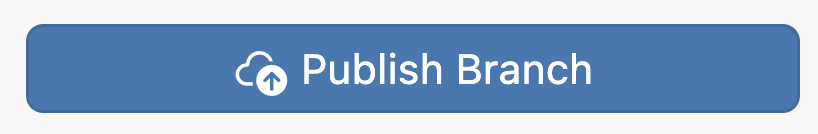

Source Control 檢視中的 Publish Branch 按鈕：藍色按鈕，左側雲端上傳圖示

**用其他主機**：先在該服務建一個空的 repository，再到 Positron 連接：開啟 Source Control 檢視的 **…** 選單 → **Remote > Add Remote** → 貼上 repository URL。之後 push 的方式各處相同。

第一次 push 之後，按鈕會變成 **Sync**：把你的新 commit 推上去，同時把協作者的新內容拉下來。

資料檔常不該進遠端 repo

尤其是大型或敏感的檔案。在 commit 前把這些檔名或模式加進 `.gitignore`，Git 就當它們不存在。

#### 日常循環順序

Review 變更（diff）→ Stage 要快照的檔案 → Commit 並附簡短訊息 → Push 到遠端。

### 關鍵詞

- **Git**：記錄專案快照的版本控制系統
- **Repository**：專案資料夾加歷史（`.git`）
- **Stage／Commit／Push**：挑變更／存快照／上傳遠端
- **Remote（遠端）**：GitHub、GitLab、Bitbucket 上的副本
- **Publish Branch／Sync**：首次推送並建立遠端／之後的雙向同步
- **`.gitignore`**：列出 Git 應忽略的檔案

### 可執行要點

- 確認終端機 `git --version` 有輸出
- 新專案勾選 Initialize Git repository；舊資料夾用 Source Control 的 Initialize Repository
- 養成「review diff → stage → commit」的小步快跑習慣
- commit 訊息寫成未來的自己看得懂的描述
- 大型或敏感資料先寫進 `.gitignore` 再 commit
- 要備份分享時用 Publish Branch（GitHub）或 Remote > Add Remote（其他主機），之後用 Sync

📝 隨堂測驗（點選項作答）

把已 stage 的變更存成附簡短訊息的快照，稱為什麼？

Commit 是存成快照；Stage 是挑變更；Push 是上傳遠端。

你有含多個 commit 的本機 repository，想備份到 GitHub，在 Positron 該怎麼做？

repository 已存在，Publish Branch 會引導登入並建立遠端 repo；Initialize 已做過。

日常循環的正確順序是？

先看 diff，再 stage，接著 commit，最後 push。

第一次 push 之後，Publish Branch 按鈕變成什麼？

Sync 會推上新 commit 並拉下協作者的新內容。

### 課程總複習（Course Recap）

Positron 入門③執行與管理程式 · 第 6 單元（總複習；第 5 單元為 Positron 內的動手實作，網頁僅有啟動按鈕，未收錄）

一句話總結

整門課濃縮成一個循環：**用範本開專案 → 寫並執行程式 → 用 notebook 探索 → commit → push**，搭配一張快捷鍵與控制項速查表即可上手。

你會學到

- 從腳本一個陳述式、選取範圍、整個檔案三種粒度執行程式碼
- 在 notebook 用程式碼儲存格、markdown 儲存格與內嵌輸出
- 用資料夾範本建專案並附 venv／renv 環境
- 用 Git 追蹤工作：review、stage、commit、push

### 內容筆記

#### 日常工作流程

任何新工作都可套用這個五步循環：

1. **開專案**：用 New Folder from Template 取得資料夾，內含專屬環境、`.gitignore`，以及（選用）Git repository
2. **寫並執行程式**：用 `Cmd/Ctrl+Enter` 逐個陳述式執行腳本，再用播放鈕跑整個檔案
3. **在 notebook 探索**：想讓結果與敘述緊貼產生它的程式碼時，用儲存格
4. **Commit**：檢視變更、stage 要放進快照的檔案、附清楚訊息 commit
5. **Push**：Publish Branch 把 repository 放上 GitHub；之後 Sync 讓本機與遠端同步

#### 速查表

| 想做的事 | 用什麼 |
| --- | --- |
| 執行當前陳述式並往下 | `Cmd/Ctrl+Enter` |
| 執行特定幾行 | 先反白，再 `Cmd/Ctrl+Enter` |
| 執行整份腳本 | 播放鈕（編輯器左上）或 `Cmd/Ctrl+Shift+Enter` |
| 執行 notebook 儲存格並移到下一格 | `Shift+Enter` |
| 建立附環境的新專案 | **New** > **New Folder from Template** |
| 切換最近的專案資料夾 | Folder Selector（右上角） |
| 檢視、stage、commit 變更 | Source Control 檢視 |
| 首次把 repository 分享到 GitHub | Source Control 的 **Publish Branch** |

#### 各單元重點回顧

- **腳本（第 1 單元）**：腳本是程式碼住的地方，session 才是跑的地方；從腳本執行的程式碼送進 Console 同一個 session，變數也在那裡。
- **Notebook（第 2 單元）**：用於探索與敘述；腳本用於管線與重用。Positron 原生編輯器是 `.ipynb` 預設編輯器，支援 Python 與 R kernel，輸出內嵌，Variables 窗格與 Data Explorer 照常運作。
- **專案與環境（第 3 單元）**：工作區就是開啟的資料夾；Python 範本預設建 `.venv`，R 範本可選 renv（`renv.lock`）。
- **Git（第 4 單元）**：commit 是快照；用 `.gitignore` 排除大型或敏感檔案；先決條件是已安裝 Git。

### 下一步（原課建議）

- 挑一件真實工作，用對的方式起頭：用範本建新資料夾，第一天就帶環境與 Git
- 小而頻繁地 commit，訊息要讓未來的自己看得懂
- 隨時參考 Positron 官方文件（隨工具演進）：Positron Notebook Editor（positron.posit.co/positron-notebook-editor.html）、Folder Templates（positron.posit.co/folder-templates.html）、Git Version Control（positron.posit.co/git.html）、Keyboard Shortcuts（positron.posit.co/keyboard-shortcuts.html）

### 可執行要點

- 挑一個真實專案，用 New Folder from Template 重建它
- 背熟三個快捷鍵：`Cmd/Ctrl+Enter`、`Cmd/Ctrl+Shift+Enter`、`Shift+Enter`
- 完成第一次 commit 並用 Publish Branch 推上 GitHub
- 閱讀上述四份官方文件
- 自己完成第 5 單元的動手實作（需在 Positron 內進行）

📝 隨堂測驗（點選項作答）

要把整份腳本從頭跑到尾，可用？

Cmd/Ctrl+Enter 只跑當前陳述式；Shift+Enter 是 notebook 儲存格。

以下哪個流程順序符合課程的日常工作流？

先用範本開專案，最後 commit 並 push。

第一次把 repository 分享到 GitHub 用什麼？

Publish Branch 引導登入並建立遠端；之後用 Sync。

由 Course2Notes 自動生成 · 內容為使用者自有課程的個人學習筆記

[figure not shown]